# Analyse du succès reproducteurs des amphibiens - Maîtrise en biologie

Author

Claudie Bouffard

**IMPORTANT:** Les codes suivants ont été générés à l’aide de ChatGPT (GPT-6 par OpenAI, 2026) et le support d’Angélique Dupuch et Katrine Turgeon

## Glossaire

### **Liste d’espèces sélectionnées :**

- **Ambystoma :** Salamandres du genre *Ambystoma*. Les espèces présentes au Québec, la salamandre maculée (*A. maculatum*), la salamandre à points bleues (*A. laterale*) et/ou salamandres du complexe de Jerfferson (*A. jeffersonianum complex*), sont incluses dans cette étude. Celles-ci sont toutes des espèces concidérées comme dépendantes des étangs vernaux et qui partagent un cycle de vie similaires.
- **LISY :** Grenouille des bois (Lithobates sylvaticus). Espèce dépendante des étangs vernaux.
- **LICL :** Grenouille verte (*Lithobates clamitans*). Espèce associée aux habitats à canopées ouvertes et étangs permanents. Représente de la compétition/prédateur pour les espèces dépendantes des étangs vernaux.
- **PSCR :** Rainette cucifère (Pseudacris crucifer). Espèce versatile et non-prédatrice des espèces dépendantes des étangs vernaux.

### **Liste de type de traitements:**

- **PEH :** Plantation de peuplier hybrides sur monticule (entre 1 à 5 ans). Les arbres sont trop jeunes pour avoir un effet sur l’hydrologie par evapotranspiration. Canopée particulièrement ouverte car les arbres sont petits.
- **CPPTM :** Coupe avec Protection des Petites Tiges Marchandes. Similaire à la coupe totale mais certains jeunes arbres sont laissés sur place. Ceux-ci ont tendance à tomber avec le vent. Sur les terres de DOMTAR, cette pratique est majoritairement dans des peuplements résineux mais a été vu dans du feuillus
- **CJ :** Coupe de Jardinage. Coupe qui imite le régime de trouée naturel des forêts de feuillus matures. Cela n’empêche la dégradation du sol par les ornières de machinerie. La canopée reste fermée.
- **NAT:** Étangs vernaux sélectionnées dans des milieux protégés depuis au moins 70 ans. Celui-ci représente le contrôle pour mon étude.

## Est-ce que l’effort de reproduction des espèces dépendantes varie-t-il selon le type de traitement sylvicole ?

Ici, l’effort de reproduction est représenté par le nombre d’oeufs pondus/m2 dans chaque étangs. Plus la densité d’oeufs est élevée, plus l’effort de reproduction a été grand.

### Ambysomes

1. **Préparation des données :**

   ```r
   library(readxl)
   library(dplyr)
   library(DHARMa)

   df <-read_excel("C:/Users/super/Université du Québec en Outaouais/CLAUDIE ÉTANGS VERNAUX - Documents/Stats/Reproduction/Oeufs/Data_base_oeufs.xlsx", sheet = 1)
   df$Traitement <- factor(df$Traitement)
   df$X <- as.numeric(scale(df$X))
   df$Y <- as.numeric(scale(df$Y))
   ```

   Ici, le X et Y est standardisé pour permettre au modèles de mieux gérer. La relation reste inchangée.

   ```r
   with(df, table(Traitement, Amby > 0))
   ```

   ```
   Traitement FALSE TRUE
        CJ        5   14
        CPPTM     9    6
        NAT       0    6
        PEH      14    2
   ```

   Ici, on peut voir que, pour PEH, seulement 2 étangs sur 16 sont colonisé par les ambystomes. Ceci est plutôt anecdotique. Ainsi, PEH sera retiré de la base de donnée.

   ```r
   df <- df[df$Traitement != "PEH", ]
   df$Traitement <- droplevels(df$Traitement)
   df
   ```

   ```
   # A tibble: 40 × 15
      No_etang  Traitement Superficie_m2  Amby  ANAM anoure  DRVE  LICA  LICL  LISE
      <chr>     <fct>              <dbl> <dbl> <dbl>  <dbl> <dbl> <dbl> <dbl> <dbl>
    1 1WATCJ6   CJ                 16.5      1     0      0     0     0     0     0
    2 2WATCJ5   CJ                 43.5      3     0      0     0     0     0     0
    3 3WATCJ1   CJ                  2.66    16     0      0     0     0     0     0
    4 4WATCJ2   CJ                 38.1      6     0      0     0     0     0     0
    5 5WATCJ4   CJ                  7.2      3     0      0     0     0     0     0
    6 6WATCJ3   CJ                 24       10     0      0     0     0     0     0
    7 15WATCPP… CPPTM               4.24     0     0      0     0     0     0     0
    8 11WATCPP… CPPTM               9.63     0     0      0     0     0     0     0
    9 10WATCPP… CPPTM              16.9      1     0      0     0     0     0     0
   10 59WATCJE… CJ                  9.81     0     0      0     0     0     0     0
   # ℹ 30 more rows
   # ℹ 5 more variables: LISY <dbl>, NOVI <dbl>, PSCR <dbl>, X <dbl>, Y <dbl>
   ```

2. **Choix de l’analyse :**

   Comme évalué durant les analyses de communautés, inclure le x et y des étangs est important pour l’intégrité de l’analyse. Par contre, il faut s’assurer qu’il n’y a pas de correlation entre traitement / X,Y. Ceci pourrait altérer la performance des modèles.

   ```r
   anova(lm(X ~ Traitement, data = df))
   ```

   ```
   Analysis of Variance Table

   Response: X
              Df Sum Sq Mean Sq F value Pr(>F)
   Traitement  2  3.415 1.70755  1.9355 0.1587
   Residuals  37 32.643 0.88224
   ```

   ```r
   anova(lm(Y ~ Traitement, data = df))
   ```

   ```
   Analysis of Variance Table

   Response: Y
              Df Sum Sq Mean Sq F value   Pr(>F)
   Traitement  2 10.807  5.4037  6.8611 0.002921 **
   Residuals  37 29.140  0.7876
   ---
   Signif. codes:  0 '***' 0.001 '**' 0.01 '*' 0.05 '.' 0.1 ' ' 1
   ```

   Le X est correct mais Y non, c’est significatif. Il y a de la correlation. C’est probablement parce que NAT est loin des autres traitements. Donc, va falloir avoir préparer les colones nécessaires pour faire une correction de la structure spaciale dans le modèle choisi. Ici, un modèle de la famille GLMM permettera d’appliquer cette correction.

   ```r
   library(glmmTMB)
   df$position <- numFactor(df$X, df$Y)
   df$groupe_spatial <- factor(1)
   ```

   numFactor() permet au modèle de reconnaitre la position de chaque étang et factor(1) s’assure que le modèle voit chaque étang comme partie de même groupe

   ```r
   with(df, table(Traitement, Amby > 0))
   ```

   ```
   Traitement FALSE TRUE
        CJ        5   14
        CPPTM     9    6
        NAT       0    6
   ```

   ```r
   summary(df$Amby)
   ```

   ```
      Min. 1st Qu.  Median    Mean 3rd Qu.    Max.
      0.00    0.00    1.00   18.60    5.25  352.00
   ```

   On voit qu’il y a beaucoup d’étangs qui ont des zéros. On a aussi une grande variation de donnée (median =1, mean=18.60, max=352). Dans une telle situation nbinom ou poisson pourrait être intéressant.

   Essayons avec nbinom2

   ```r
   library(glmmTMB)
   mod1_1 <- glmmTMB(Amby ~ Traitement +exp(position + 0 | groupe_spatial)+offset(log(Superficie_m2)),family = nbinom2(link = "log"),data = df)
   ```

   offset permet de prendre en compte la superficie des étangs qui varie beaucoup d’étang en étang. le link=‘log’ permet de s’assurer de ne pas avoir un nombre d’oeufs prédit négatif ce qui ne ferait pas biologiquement de sens. L’ajout de exp(position + 0 | groupe_spatia) explique au modèle que les étangs proches les uns des autres pourrait avoir des similarités. Le ’‘+0’’ permet de ne pas inclure les intercept.

   ```
   [1] FALSE
   ```

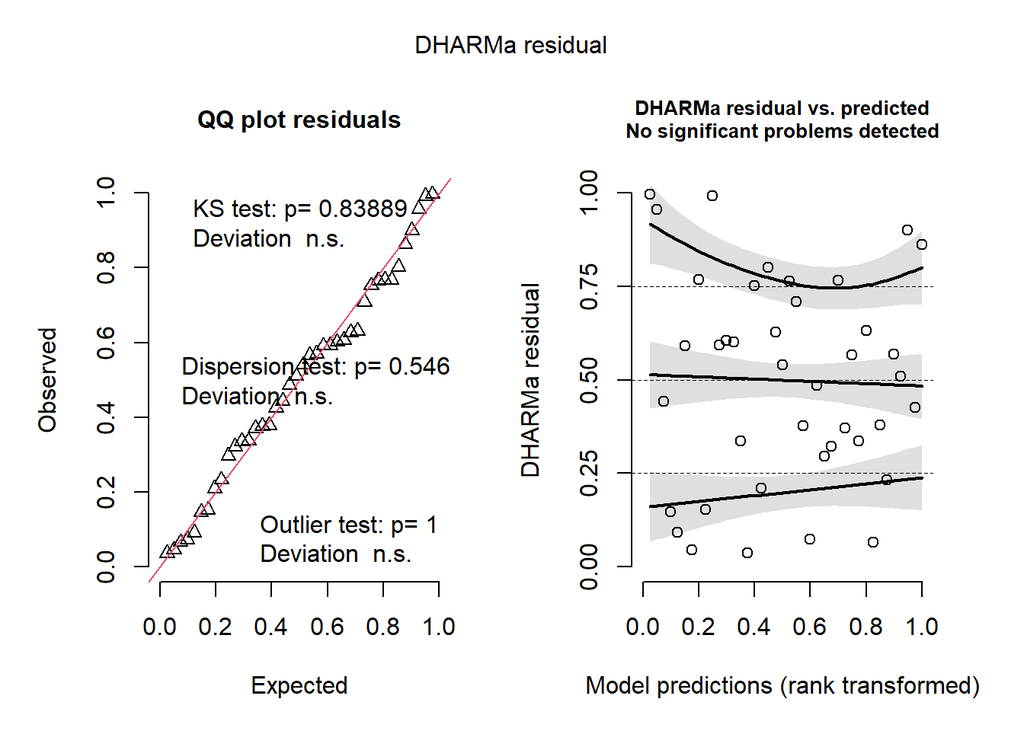

   ```r
   plot(res1_1)
   ```

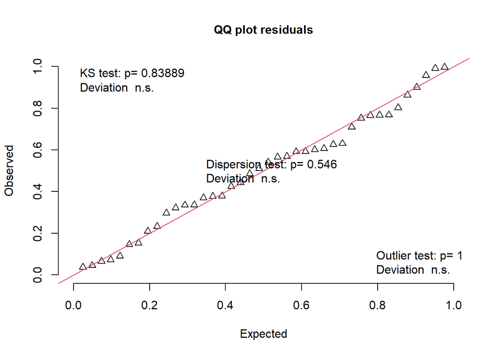

   ```
       Exact one-sample Kolmogorov-Smirnov test

   data:  simulationOutput$scaledResiduals
   D = 0.094014, p-value = 0.8389
   alternative hypothesis: two-sided
   ```

   ```r
   testUniformity(res1_1) #ok
   ```

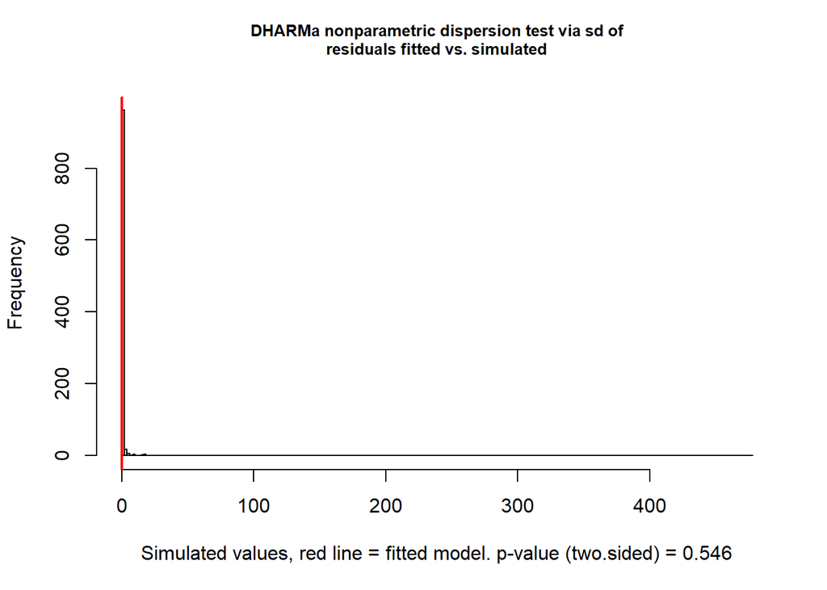

   ```
       DHARMa nonparametric dispersion test via sd of residuals fitted vs.
       simulated

   data:  simulationOutput
   dispersion = 0.082903, p-value = 0.546
   alternative hypothesis: two.sided
   ```

   ```r
   testDispersion(res1_1) #ok
   ```

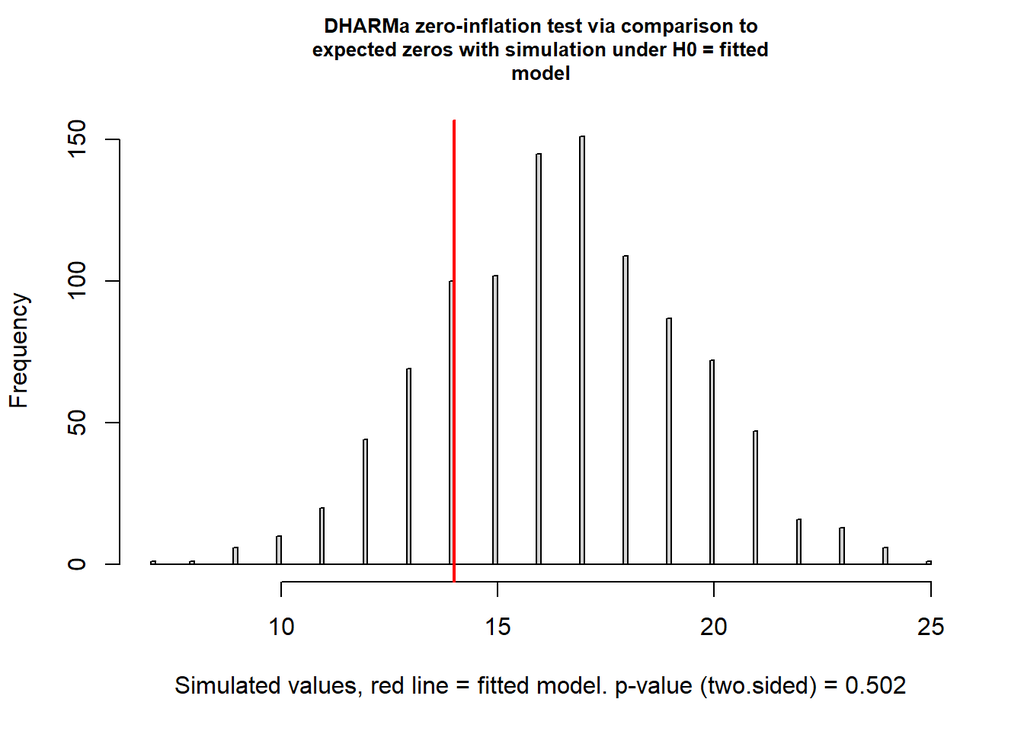

   ```
       DHARMa zero-inflation test via comparison to expected zeros with
       simulation under H0 = fitted model

   data:  simulationOutput
   ratioObsSim = 0.84884, p-value = 0.502
   alternative hypothesis: two.sided
   ```

   ```r
   testZeroInflation(res1_1) #ok
   ```

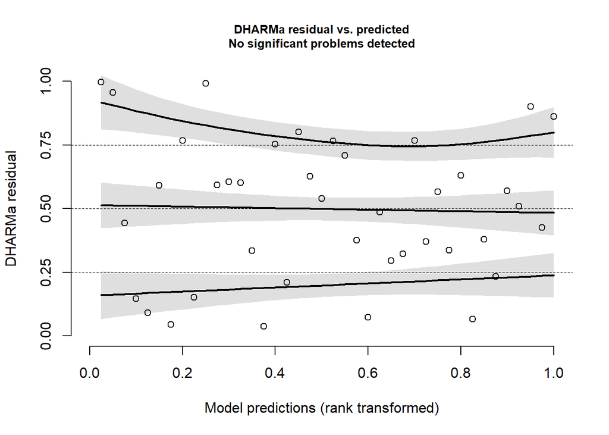

   ```
       Test for location of quantiles via qgam

   data:  res
   p-value = 0.788
   alternative hypothesis: both
   ```

   ```r
   testQuantiles(res1_1) #ok
   ```

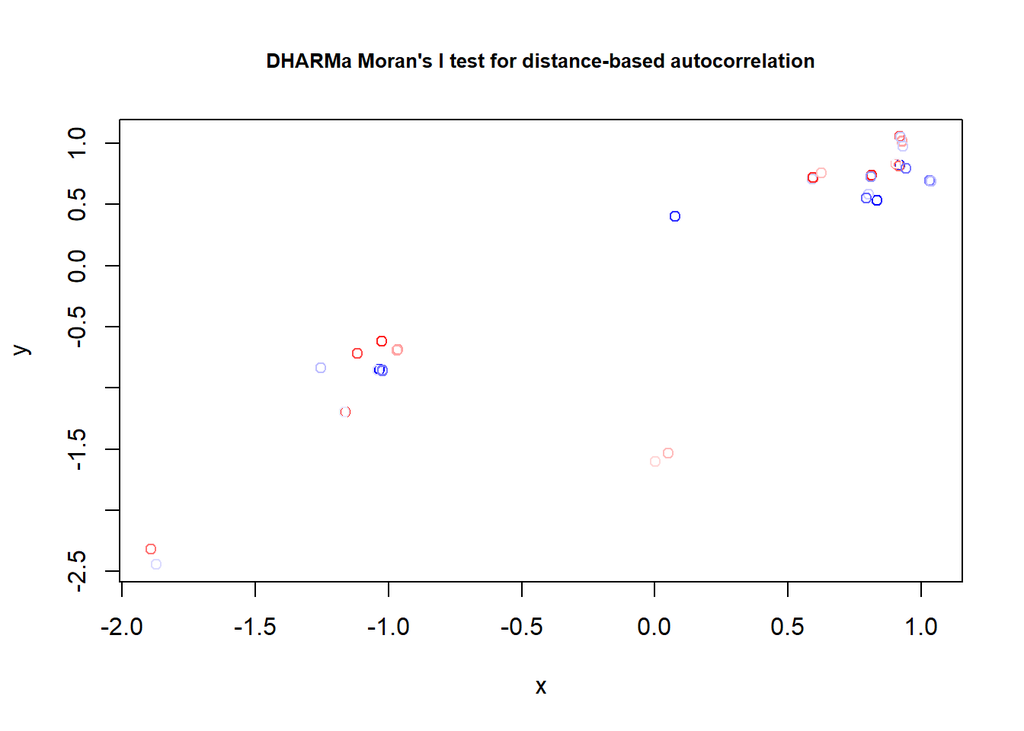

   ```
       DHARMa Moran's I test for distance-based autocorrelation

   data:  res1_1
   observed = 0.127754, expected = -0.025641, sd = 0.130105, p-value =
   0.2384
   alternative hypothesis: Distance-based autocorrelation
   ```

   ```r
   testSpatialAutocorrelation(res1_1,x = df$X,y = df$Y) #ok
   ```

   Les résultats de DHARMa ressortent bien, rien de significatif
3. **Analyse :**

   ```r
   library(emmeans)
   summary(mod1_1) #le mod agit comme poisson
   ```

   ```
    Family: nbinom2  ( log )
   Formula:
   Amby ~ Traitement + exp(position + 0 | groupe_spatial) + offset(log(Superficie_m2))
   Data: df

         AIC       BIC    logLik -2*log(L)  df.resid
          NA        NA        NA        NA        34

   Random effects:

   Conditional model:
    Groups         Name                                           Variance
    groupe_spatial position(-1.87312780864869,-2.44379214732412)  2.593
                   position(-1.89260956533392,-2.31527014729717)  2.593
                   position(0.00179742397988789,-1.6051749793282) 2.593
                   position(0.0514468262784515,-1.53090794125034) 2.593
                   position(-1.16492718347538,-1.19715098270285)  2.593
                   position(-1.16420025225578,-1.1949830077889)   2.593
                   position(-1.02366021646677,-0.858780128825668) 2.593
                   position(-1.02256981963738,-0.856945688513865) 2.593
                   position(-1.03851384438723,-0.854221822596339) 2.593
                   position(-1.03441879851683,-0.846550526746979) 2.593
                   ...                                            ...
    Std.Dev. Corr
    1.61
    1.61     0.00
    1.61     0.00 0.00
    1.61     0.00 0.00 0.00
    1.61     0.00 0.00 0.00 0.00
    1.61     0.00 0.00 0.00 0.00 0.85
    1.61     0.00 0.00 0.00 0.00 0.00 0.00
    1.61     0.00 0.00 0.00 0.00 0.00 0.00 0.86
    1.61     0.00 0.00 0.00 0.00 0.00 0.00 0.33 0.32
    1.61     0.00 0.00 0.00 0.00 0.00 0.00 0.32 0.33 0.54
    ...      ...  ...  ...  ...  ...  ...  ...  ...  ...  ...
   Number of obs: 40, groups:  groupe_spatial, 1

   Dispersion parameter for nbinom2 family (): 6.61e+07

   Conditional model:
                   Estimate Std. Error z value Pr(>|z|)
   (Intercept)      -2.1141     0.5508  -3.838 0.000124 ***
   TraitementCPPTM  -1.1290     0.8626  -1.309 0.190617
   TraitementNAT     0.2902     0.9153   0.317 0.751230
   ---
   Signif. codes:  0 '***' 0.001 '**' 0.01 '*' 0.05 '.' 0.1 ' ' 1
   ```

   ```r
   com1 <- emmeans(mod1_1, pairwise ~ Traitement,type = "response", adjust = "holm")
   com1$contrasts
   ```

   ```
    contrast    ratio    SE  df null z.ratio p.value
    CJ / CPPTM  3.093 2.670 Inf    1   1.309  0.4814
    CJ / NAT    0.748 0.685 Inf    1  -0.317  0.7512
    CPPTM / NAT 0.242 0.245 Inf    1  -1.404  0.4814

   P value adjustment: holm method for 3 tests
   Tests are performed on the log scale
   ```

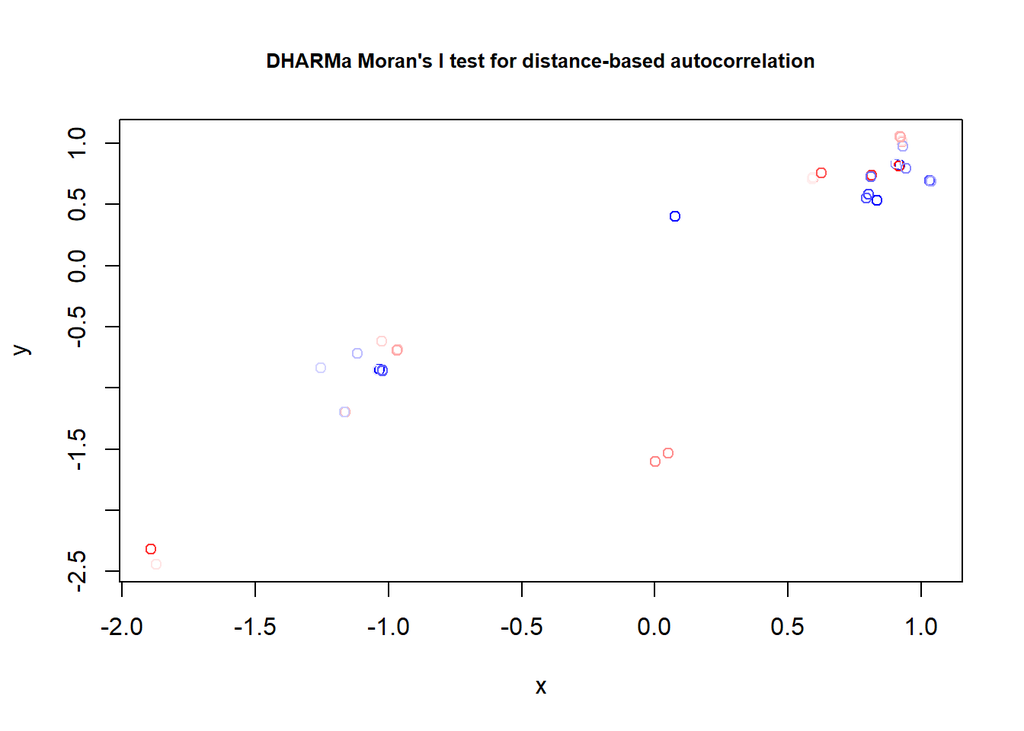

   ```
       DHARMa Moran's I test for distance-based autocorrelation

   data:  res2_1
   observed = 0.232963, expected = -0.025641, sd = 0.130258, p-value =
   0.04711
   alternative hypothesis: Distance-based autocorrelation
   ```

   ```r
   #NBINOM1
   mod2_1 <- glmmTMB(Amby ~ Traitement +exp(position + 0 | groupe_spatial)+offset(log(Superficie_m2)),family = nbinom1(link = "log"),data = df)
   res2_1 <- simulateResiduals(fittedModel = mod2_1,n = 1000)
   testSpatialAutocorrelation(res2_1,x = df$X,y = df$Y) #pas ok
   ```

   ```r
   summary(mod2_1)
   ```

   ```
    Family: nbinom1  ( log )
   Formula:
   Amby ~ Traitement + exp(position + 0 | groupe_spatial) + offset(log(Superficie_m2))
   Data: df

         AIC       BIC    logLik -2*log(L)  df.resid
       207.5     217.7     -97.8     195.5        34

   Random effects:

   Conditional model:
    Groups         Name                                           Variance
    groupe_spatial position(-1.87312780864869,-2.44379214732412)  0.9594
                   position(-1.89260956533392,-2.31527014729717)  0.9594
                   position(0.00179742397988789,-1.6051749793282) 0.9594
                   position(0.0514468262784515,-1.53090794125034) 0.9594
                   position(-1.16492718347538,-1.19715098270285)  0.9594
                   position(-1.16420025225578,-1.1949830077889)   0.9594
                   position(-1.02366021646677,-0.858780128825668) 0.9594
                   position(-1.02256981963738,-0.856945688513865) 0.9594
                   position(-1.03851384438723,-0.854221822596339) 0.9594
                   position(-1.03441879851683,-0.846550526746979) 0.9594
                   ...                                            ...
    Std.Dev. Corr
    0.9795
    0.9795   0.28
    0.9795   0.00 0.00
    0.9795   0.00 0.00 0.41
    0.9795   0.00 0.00 0.00 0.00
    0.9795   0.00 0.00 0.00 0.00 0.98
    0.9795   0.00 0.00 0.00 0.00 0.03 0.03
    0.9795   0.00 0.00 0.00 0.00 0.03 0.03 0.98
    0.9795   0.00 0.00 0.00 0.00 0.03 0.03 0.86 0.85
    0.9795   0.00 0.00 0.00 0.00 0.02 0.03 0.85 0.86 0.92
    ...      ...  ...  ...  ...  ...  ...  ...  ...  ...  ...
   Number of obs: 40, groups:  groupe_spatial, 1

   Dispersion parameter for nbinom1 family (): 2.62

   Conditional model:
                   Estimate Std. Error z value Pr(>|z|)
   (Intercept)      -1.9843     0.5078  -3.907 9.33e-05 ***
   TraitementCPPTM  -0.5622     0.7342  -0.766    0.444
   TraitementNAT     0.5088     0.7339   0.693    0.488
   ---
   Signif. codes:  0 '***' 0.001 '**' 0.01 '*' 0.05 '.' 0.1 ' ' 1
   ```

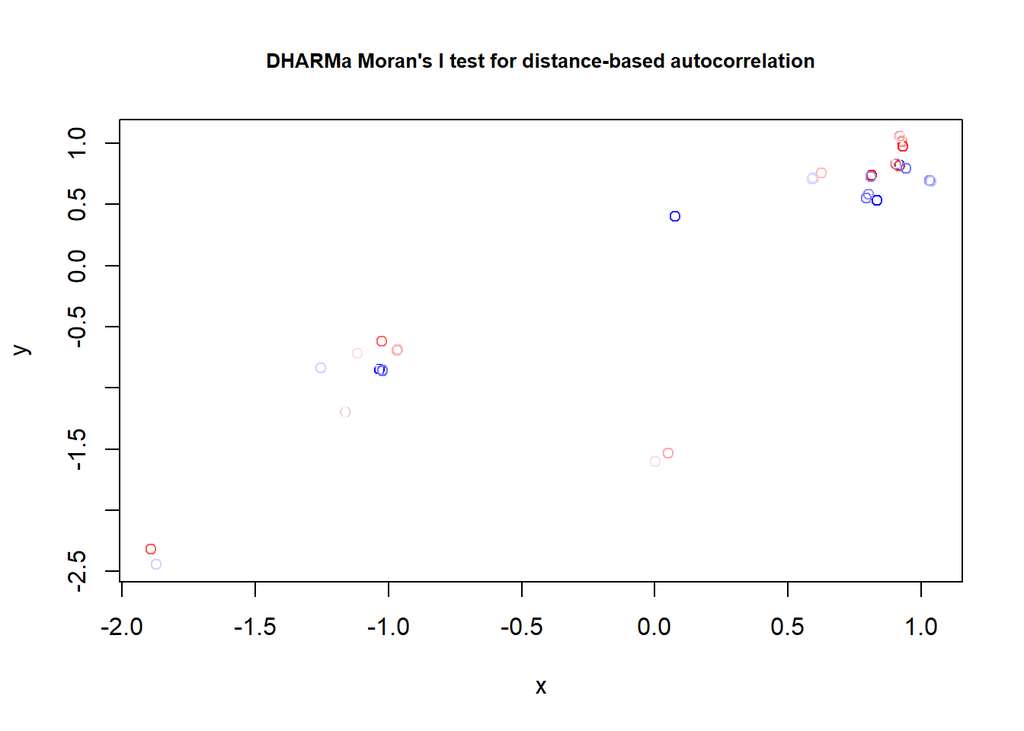

   ```
       DHARMa Moran's I test for distance-based autocorrelation

   data:  res3_1
   observed = 0.206338, expected = -0.025641, sd = 0.130100, p-value =
   0.07457
   alternative hypothesis: Distance-based autocorrelation
   ```

   ```r
   #POISSON
   mod3_1 <- glmmTMB(Amby ~ Traitement +exp(position + 0 | groupe_spatial)+offset(log(Superficie_m2)),family = poisson(link = "log"),data = df)
   res3_1 <- simulateResiduals(fittedModel = mod3_1,n = 1000)
   testSpatialAutocorrelation(res3_1,x = df$X,y = df$Y) #pas ok
   ```

   ```r
   summary(mod3_1)
   ```

   ```
    Family: poisson  ( log )
   Formula:
   Amby ~ Traitement + exp(position + 0 | groupe_spatial) + offset(log(Superficie_m2))
   Data: df

         AIC       BIC    logLik -2*log(L)  df.resid
       201.5     210.0     -95.8     191.5        35

   Random effects:

   Conditional model:
    Groups         Name                                           Variance
    groupe_spatial position(-1.87312780864869,-2.44379214732412)  2.593
                   position(-1.89260956533392,-2.31527014729717)  2.593
                   position(0.00179742397988789,-1.6051749793282) 2.593
                   position(0.0514468262784515,-1.53090794125034) 2.593
                   position(-1.16492718347538,-1.19715098270285)  2.593
                   position(-1.16420025225578,-1.1949830077889)   2.593
                   position(-1.02366021646677,-0.858780128825668) 2.593
                   position(-1.02256981963738,-0.856945688513865) 2.593
                   position(-1.03851384438723,-0.854221822596339) 2.593
                   position(-1.03441879851683,-0.846550526746979) 2.593
                   ...                                            ...
    Std.Dev. Corr
    1.61
    1.61     0.00
    1.61     0.00 0.00
    1.61     0.00 0.00 0.00
    1.61     0.00 0.00 0.00 0.00
    1.61     0.00 0.00 0.00 0.00 0.85
    1.61     0.00 0.00 0.00 0.00 0.00 0.00
    1.61     0.00 0.00 0.00 0.00 0.00 0.00 0.86
    1.61     0.00 0.00 0.00 0.00 0.00 0.00 0.33 0.32
    1.61     0.00 0.00 0.00 0.00 0.00 0.00 0.32 0.33 0.54
    ...      ...  ...  ...  ...  ...  ...  ...  ...  ...  ...
   Number of obs: 40, groups:  groupe_spatial, 1

   Conditional model:
                   Estimate Std. Error z value Pr(>|z|)
   (Intercept)      -2.1141     0.5508  -3.838 0.000124 ***
   TraitementCPPTM  -1.1290     0.8626  -1.309 0.190617
   TraitementNAT     0.2902     0.9153   0.317 0.751233
   ---
   Signif. codes:  0 '***' 0.001 '**' 0.01 '*' 0.05 '.' 0.1 ' ' 1
   ```

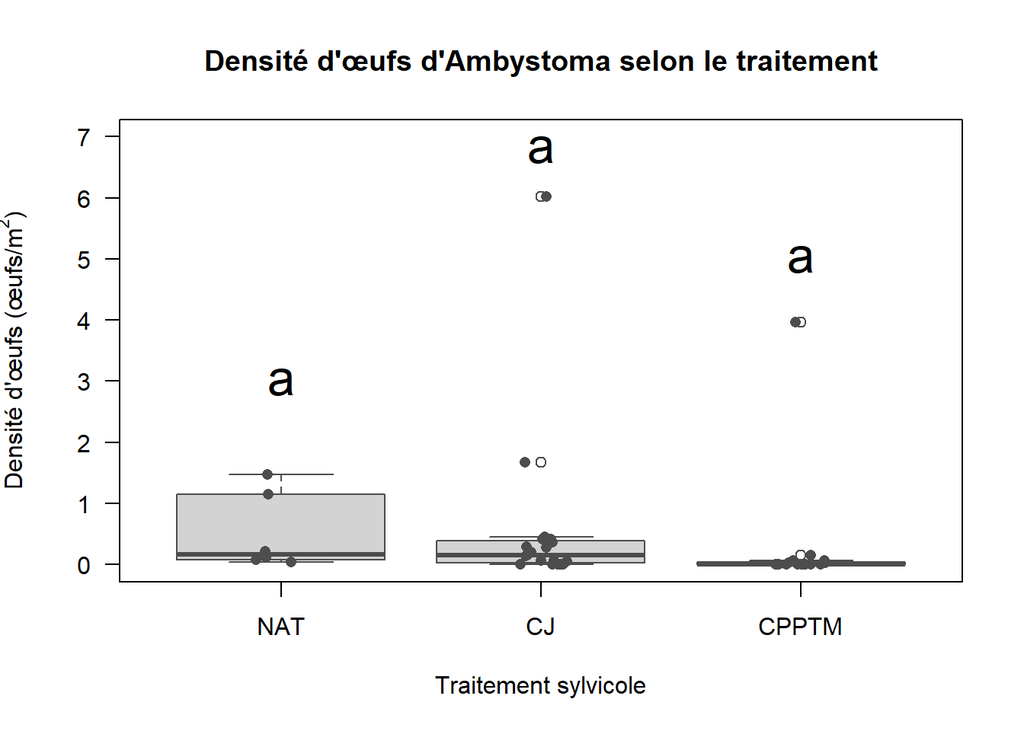

   ```r
   df_V <- read_excel("C:/Users/super/Université du Québec en Outaouais/CLAUDIE ÉTANGS VERNAUX - Documents/Stats/Reproduction/Oeufs/Data_base_oeufs.xlsx", sheet = 2)
   df_V$Traitement <- factor(df_V$Traitement,levels = c("NAT", "CJ", "CPPTM"))
   df_V <- df_V[df_V$Traitement != "PEH", ] #Enlève PEH. On a juste 2 étangs qui ont des salamandres. C'est anecdotique
   boxplot(Amby ~ Traitement,
           data = df_V,
           xlab = "Traitement sylvicole",
           ylab = expression("Densité d'œufs (œufs/m"^2*")"),
           main = "Densité d'œufs d'Ambystoma selon le traitement",
           border = "gray30",
           las = 1,
           ylim = c(0, 7))
   stripchart(Amby ~ Traitement,
              data = df_V,
              vertical = TRUE,
              method = "jitter",
              pch = 16,
              col = "gray30",
              add = TRUE)
   text(x = 1, y = 3, labels = "a", cex = 2)
   text(x = 2, y = 6.8, labels = "a", cex = 2)
   text(x = 3, y = 5, labels = "a", cex = 2)
   ```

### LISY

1. **Préparation des données :**

   ```r
   df2 <-read_excel("C:/Users/super/Université du Québec en Outaouais/CLAUDIE ÉTANGS VERNAUX - Documents/Stats/Reproduction/Oeufs/Data_base_oeufs.xlsx", sheet = 1)
   df2$Traitement <- factor(df2$Traitement)
   df2$X <- as.numeric(scale(df2$X))
   df2$Y <- as.numeric(scale(df2$Y))
   df2
   ```

   ```
   # A tibble: 56 × 15
      No_etang  Traitement Superficie_m2  Amby  ANAM anoure  DRVE  LICA  LICL  LISE
      <chr>     <fct>              <dbl> <dbl> <dbl>  <dbl> <dbl> <dbl> <dbl> <dbl>
    1 1WATCJ6   CJ                 16.5      1     0      0     0     0     0     0
    2 2WATCJ5   CJ                 43.5      3     0      0     0     0     0     0
    3 3WATCJ1   CJ                  2.66    16     0      0     0     0     0     0
    4 4WATCJ2   CJ                 38.1      6     0      0     0     0     0     0
    5 5WATCJ4   CJ                  7.2      3     0      0     0     0     0     0
    6 6WATCJ3   CJ                 24       10     0      0     0     0     0     0
    7 17WATPEH… PEH                 6.21     0     0      0     0     0     0     0
    8 7WATPEH2  PEH                26.7      0     0      0     0     0     0     0
    9 12WATPEH5 PEH                57.4      0     0      0     0     0     0     0
   10 8WATPEH1  PEH                13.4      0     0      0     0     0     0     0
   # ℹ 46 more rows
   # ℹ 5 more variables: LISY <dbl>, NOVI <dbl>, PSCR <dbl>, X <dbl>, Y <dbl>
   ```

2. **Choix de l’analyse :**

   ```r
   summary(df2$LISY)
   ```

   ```
      Min. 1st Qu.  Median    Mean 3rd Qu.    Max.
     0.000   1.000   2.000   9.696   6.500 189.000
   ```

   Ici, on a une distribution super asymétrique: La moyenne est de 9,696, alors que la médiane est de seulement 2. Le maximum 189. Un GLM negative binomial serait intéressant.

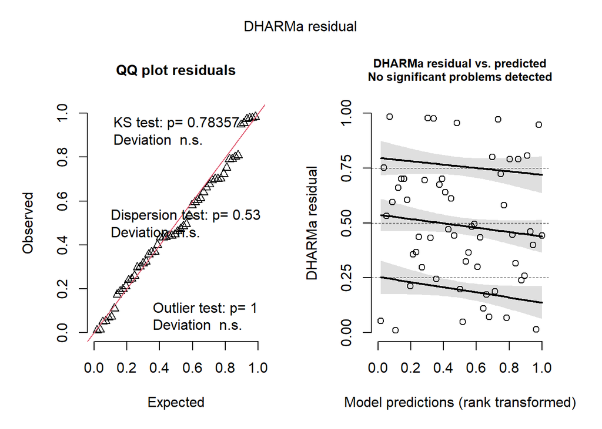

   ```r
   library(MASS)
   mod3 <- glm.nb(LISY ~ Traitement + X + Y +offset(log(Superficie_m2)),data = df2)
   res3 <- simulateResiduals(fittedModel = mod3,n = 1000)
   plot(res3) #Nice
   ```

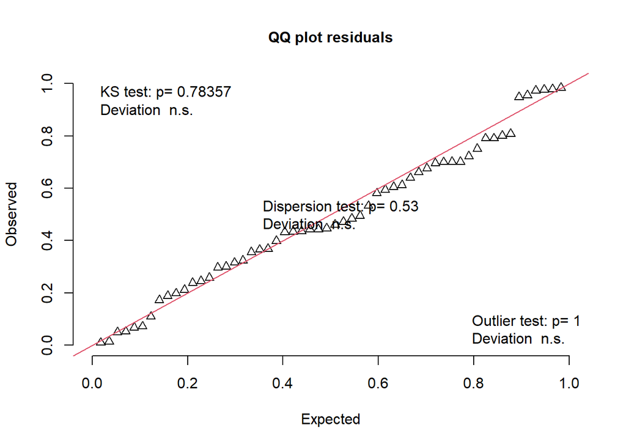

   ```
       Exact one-sample Kolmogorov-Smirnov test

   data:  simulationOutput$scaledResiduals
   D = 0.084825, p-value = 0.7836
   alternative hypothesis: two-sided
   ```

   ```r
   testUniformity(res3) #ok
   ```

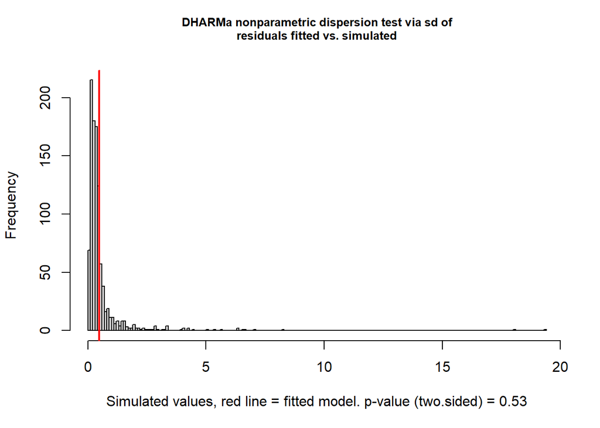

   ```
       DHARMa nonparametric dispersion test via sd of residuals fitted vs.
       simulated

   data:  simulationOutput
   dispersion = 0.85047, p-value = 0.53
   alternative hypothesis: two.sided
   ```

   ```r
   testDispersion(res3) #ok
   ```

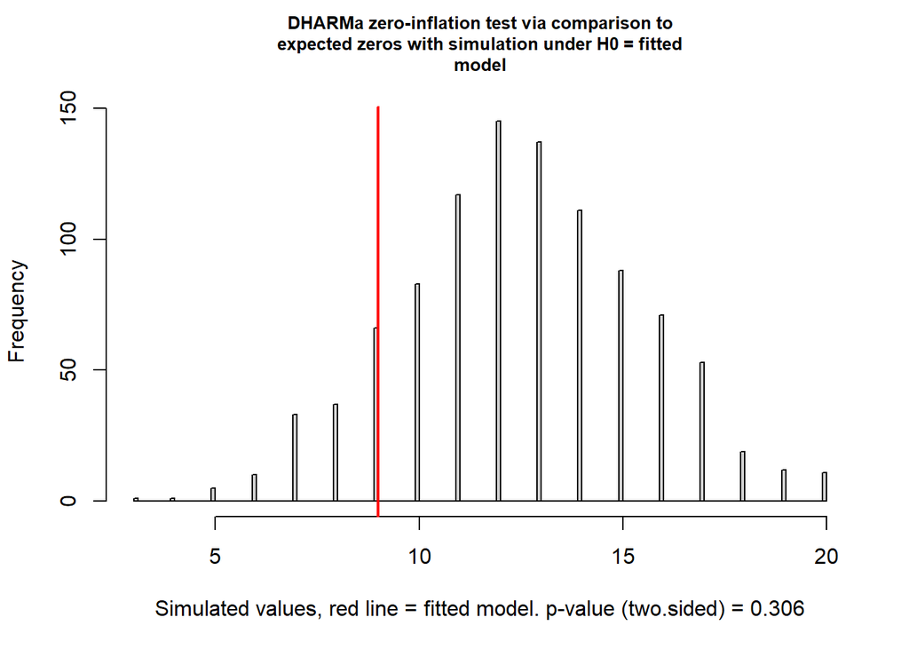

   ```
       DHARMa zero-inflation test via comparison to expected zeros with
       simulation under H0 = fitted model

   data:  simulationOutput
   ratioObsSim = 0.71702, p-value = 0.306
   alternative hypothesis: two.sided
   ```

   ```r
   testZeroInflation(res3) #ok
   ```

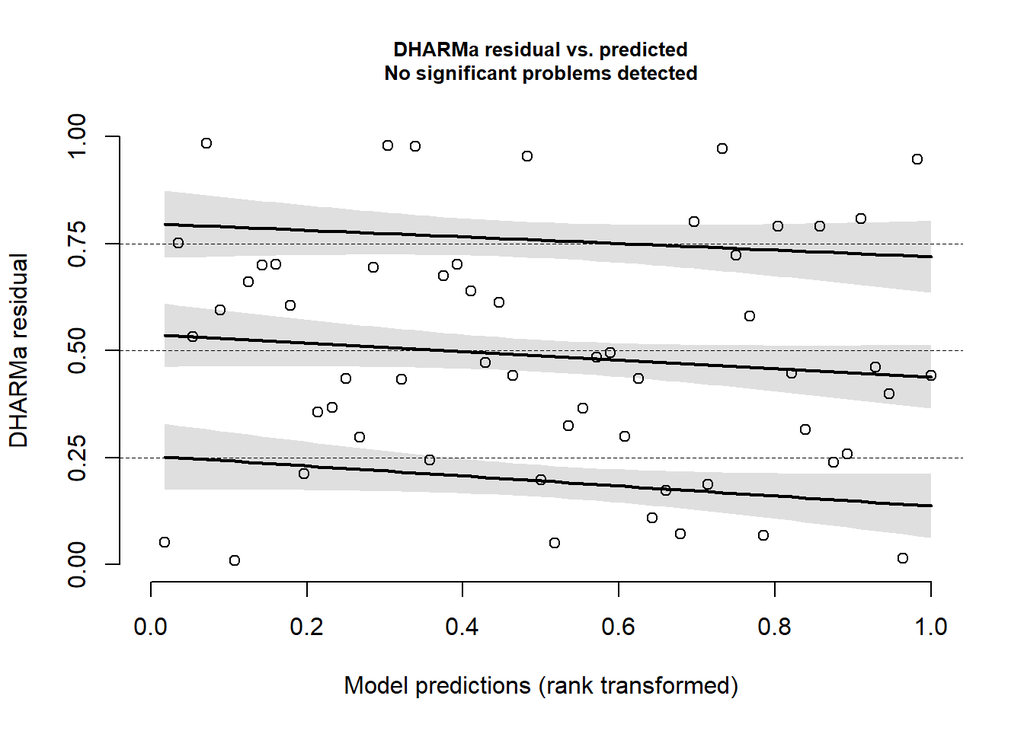

   ```
       Test for location of quantiles via qgam

   data:  res
   p-value = 0.8186
   alternative hypothesis: both
   ```

   ```r
   testQuantiles(res3) #ok
   ```

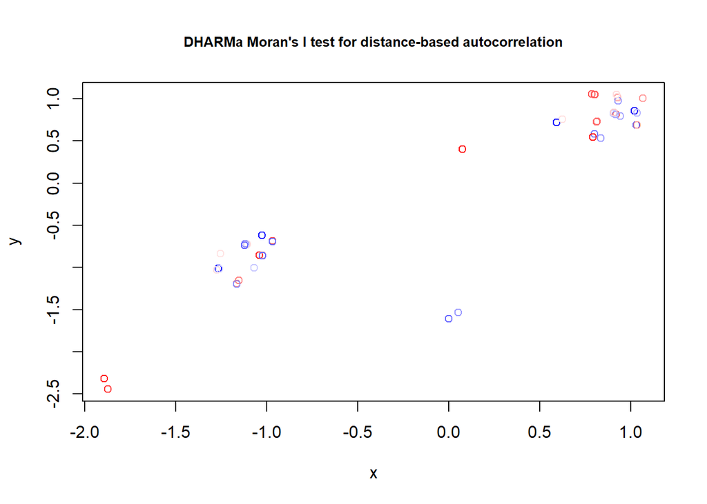

   ```
       DHARMa Moran's I test for distance-based autocorrelation

   data:  res3
   observed = -0.144526, expected = -0.018182, sd = 0.095928, p-value =
   0.1878
   alternative hypothesis: Distance-based autocorrelation
   ```

   ```r
   testSpatialAutocorrelation(res3,x = df2$X,y = df2$Y) #ok
   ```

   Tout semble bien ici.

   *Note:  
   J’ai essayé Poisson et c’était pas du tout adapté.

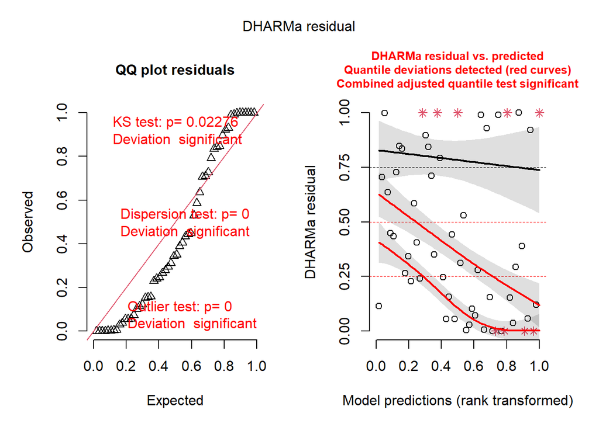

   ```r
   mod2 <- glm(LISY ~ Traitement + X + Y +offset(log(Superficie_m2)),family=poisson(link = "log"), data = df2)
   res2 <- simulateResiduals(fittedModel = mod2,n = 1000)
   plot(res2) #attroce!
   ```

3. **Analyse :**

   ```r
   summary(mod3)
   ```

   ```
   Call:
   glm.nb(formula = LISY ~ Traitement + X + Y + offset(log(Superficie_m2)),
       data = df2, init.theta = 1.010863568, link = log)

   Coefficients:
                   Estimate Std. Error z value Pr(>|z|)
   (Intercept)      -1.3836     0.2794  -4.952 7.33e-07 ***
   TraitementCPPTM   0.7823     0.4001   1.955   0.0506 .
   TraitementNAT    -0.4253     0.6084  -0.699   0.4845
   TraitementPEH     0.1171     0.3965   0.295   0.7678
   X                -0.5830     0.4648  -1.254   0.2098
   Y                 0.6574     0.4878   1.348   0.1778
   ---
   Signif. codes:  0 '***' 0.001 '**' 0.01 '*' 0.05 '.' 0.1 ' ' 1

   (Dispersion parameter for Negative Binomial(1.0109) family taken to be 1)

       Null deviance: 71.464  on 55  degrees of freedom
   Residual deviance: 60.413  on 50  degrees of freedom
   AIC: 315.29

   Number of Fisher Scoring iterations: 1

                 Theta:  1.011
             Std. Err.:  0.237

    2 x log-likelihood:  -301.290
   ```

   On semble avoir une tendance. CJ semble être différent de CPPPTM. Par contre, ce n’est pas significatif. Tout le reste n’est pas significatif non plus
4. **Visualisation :**

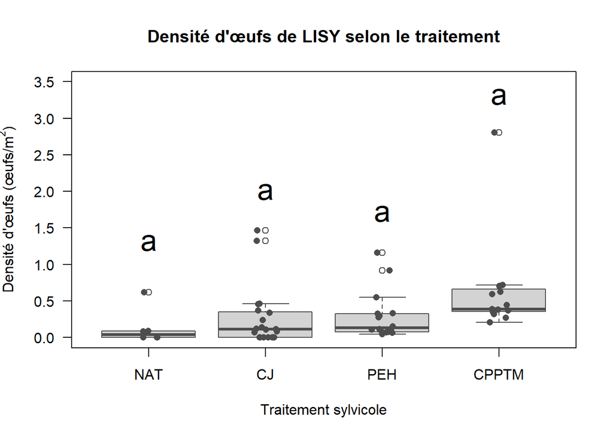

   ```r
   df_V <- read_excel("C:/Users/super/Université du Québec en Outaouais/CLAUDIE ÉTANGS VERNAUX - Documents/Stats/Reproduction/Oeufs/Data_base_oeufs.xlsx", sheet = 2)
   df_V$Traitement <- factor(df_V$Traitement,levels = c("NAT", "CJ", 'PEH', "CPPTM"))
   boxplot(LISY ~ Traitement,
           data = df_V,
           xlab = "Traitement sylvicole",
           ylab = expression("Densité d'œufs (œufs/m"^2*")"),
           main = "Densité d'œufs de LISY selon le traitement",
           border = "gray30",
           las = 1,
           ylim = c(0, 3.5))
   stripchart(LISY ~ Traitement,
              data = df_V,
              vertical = TRUE,
              method = "jitter",
              pch = 16,
              col = "gray30",
              add = TRUE)
   text(x = 1, y = 1.3, labels = "a", cex = 2)
   text(x = 2, y = 2, labels = "a", cex = 2)
   text(x = 3, y = 1.7, labels = "a", cex = 2)
   text(x = 4, y = 3.3, labels = "a", cex = 2)
   ```

   n NAT = 6 , n CJ = 14 , n PEH =16 , n CPPTM=13

### Visuel combiné

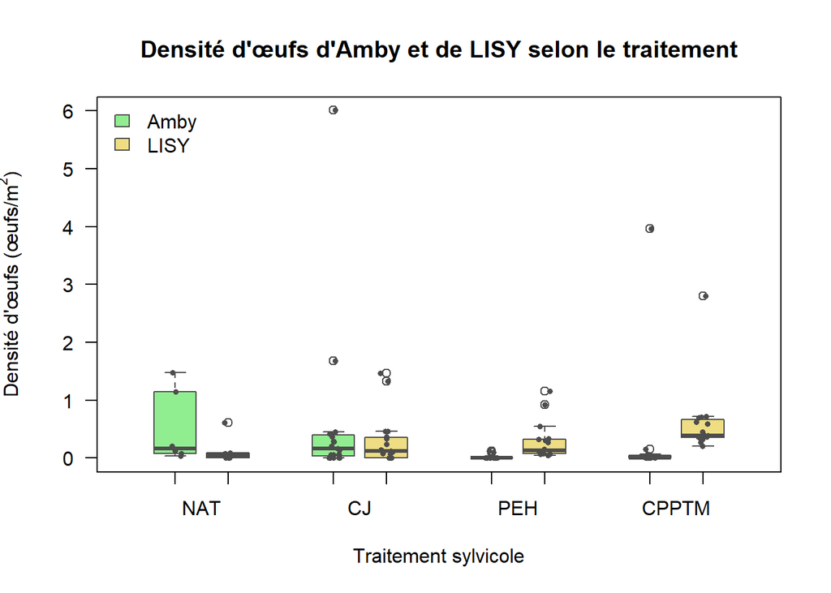

```r
df_V <- read_excel("C:/Users/super/Université du Québec en Outaouais/CLAUDIE ÉTANGS VERNAUX - Documents/Stats/Reproduction/Oeufs/Data_base_oeufs.xlsx",sheet = 2)

# Ordre des traitements
df_V$Traitement <- factor(df_V$Traitement,levels = c("NAT", "CJ", "PEH", "CPPTM"))

# Préparer les données : Amby puis LISY pour chaque traitement
donnees <- list(
  df_V$Amby[df_V$Traitement == "NAT"],
  df_V$LISY[df_V$Traitement == "NAT"],
  df_V$Amby[df_V$Traitement == "CJ"],
  df_V$LISY[df_V$Traitement == "CJ"],
  df_V$Amby[df_V$Traitement == "PEH"],
  df_V$LISY[df_V$Traitement == "PEH"],
  df_V$Amby[df_V$Traitement == "CPPTM"],
  df_V$LISY[df_V$Traitement == "CPPTM"]
)

# Positions des boîtes sur l'axe X
pos <- c(1, 2, 4, 5, 7, 8, 10, 11)

# Couleurs
couleurs <- rep(c("lightgreen", "lightgoldenrod"),4)

# Graphique combiné
boxplot(donnees,
  at = pos,
  names = rep("", length(pos)),
  xlim = c(0, 12),
  ylim = c(0, 6),
  xlab = "Traitement sylvicole",
  ylab = expression("Densité d'œufs (œufs/m"^2*")"),
  main = "Densité d'œufs d'Amby et de LISY selon le traitement",
  col = couleurs,
  border = "gray30",
  las = 1)

# Ajouter les points individuels
for (i in seq_along(donnees)) {
  points(
    jitter(rep(pos[i], length(donnees[[i]])), amount = 0.12),
    donnees[[i]],
    pch = 16,
    cex = 0.6,
    col = "gray30")
}

# Noms des traitements
axis(1,at = c(1.5, 4.5, 7.5, 10.5),labels = c("NAT", "CJ", "PEH", "CPPTM"),tick = FALSE)

# Légende
legend(
  "topleft",
  legend = c("Amby", "LISY"),
  fill = c("lightgreen", "lightgoldenrod"),
  border = "gray30",
  bty = "n"
)
```

Le type de traitement ne semble pas affecter significativement l’effort de reproduction (ponte d’oeuf). En effet, on voit que la majorité des boites se chevauchent, même entre ambystomes et lisy. Si on pousse, on pourrait peut-être voir une tendance pour LISY avec peut-être plus d’oeufs dans CPPTM

## Est-ce que le SLV varie selon le type de traitement ?

Note:  
SLV signifie Snout to Vent Length. Pour cette étude, ceci a été calculé en mm. La grosseur des larves est un indicateur de la qualité de l’habitat. Selon la littérature, plus les larves seraient grosses, plus la qualité de l’habitat serait bonne.  
Dans la base de donnée le SVL choisi représente la moyenne entre le SVL Max et SVL Min documenté à la dernière journée de prise de donnée pour l’étang (donc juste avant la mort ou métamorphose des larves, leur donnant autant de temps que possible de développement)

### Ambystome :

1. **Préparation des données :**

   ```r
   df <-read_excel("C:/Users/super/Université du Québec en Outaouais/CLAUDIE ÉTANGS VERNAUX - Documents/Stats/Reproduction/Larves/Bio_DataBase_tetard.xlsx", sheet = 1)
   df <- df[df$amby != 0, ]
   df
   ```

   ```
   # A tibble: 16 × 14
      No_etang    Traitement  ANAM  amby anoure  DRVE  LICA  LICL  LISE  LISY  NOVI
      <chr>       <chr>      <dbl> <dbl>  <dbl> <dbl> <dbl> <dbl> <dbl> <dbl> <dbl>
    1 4WATCJ2     CJ             0  20        0     0     0   0       0   0       0
    2 5WATCJ4     CJ             0  14        0     0     0   0       0  16       0
    3 6WATCJ3     CJ             0  11        0     0     0   0       0  12       0
    4 10WATCPPTM5 CPPTM          0  27        0    16     0   0       0  13       0
    5 58WATCPPTM… CPPTM          0  15        0     0     0   0       0  13.5     0
    6 24DORCJ11   CJ             0  18        0     0     0   0       0  16.5     0
    7 25DORCJ12   CJ             0  22        0     0     0  43       0  20       0
    8 30DORPEH8   PEH            0  25        0     0     0  15       0  12       0
    9 36DORCJ2    CJ             0  29.5      0     0     0   0       0  18       0
   10 40DORCJ8    CJ             0  23        0     0     0  12.5     0  17       0
   11 45DORCPPTM7 CPPTM          0  14        0     0     0   0       0  14       0
   12 43DORCJ4    CJ             0  15        0     0     0   0       0   0       0
   13 50DORCPPTM3 CPPTM          0  28        0     0     0   3       0  11.5     0
   14 18FRONT5    NAT            0  17        0     0     0   0       0  16.5     0
   15 19FRONT5    NAT            0  16.5      0     0     0   0       0  17       0
   16 56MEGEX1    NAT            0  22        0     0     0   0       0  16       0
   # ℹ 3 more variables: PSCR <dbl>, X <dbl>, Y <dbl>
   ```

2. **Visualisation :**

   J’ai vraiment pas beaucoup de donnée. Pas certaine que je pourrai faire un analyse statistique qui fait du sens.

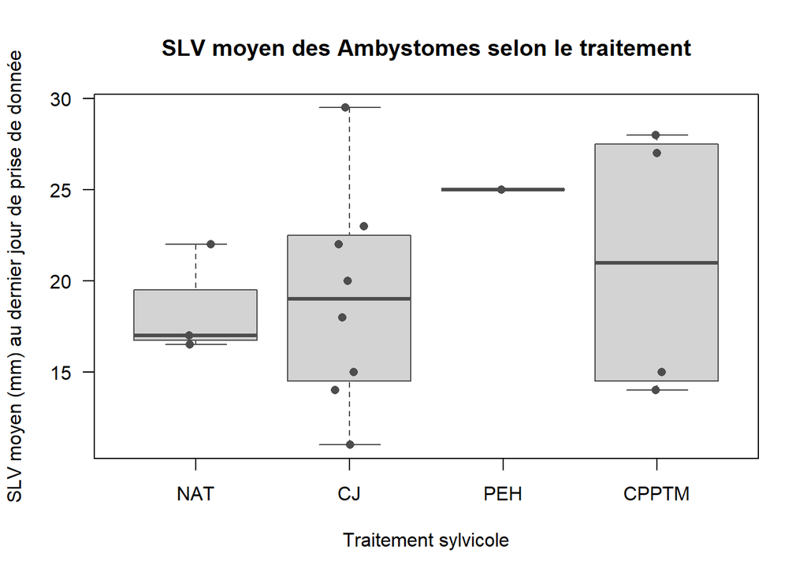

   ```r
   df$Traitement <- factor(df$Traitement,levels = c("NAT", "CJ", 'PEH', "CPPTM"))
   boxplot(amby ~ Traitement,
           data = df,
           xlab = "Traitement sylvicole",
           ylab = 'SLV moyen (mm) au dernier jour de prise de donnée',
           main = "SLV moyen des Ambystomes selon le traitement",
           border = "gray30",
           las = 1)
   stripchart(amby ~ Traitement,
              data = df,
              vertical = TRUE,
              method = "jitter",
              pch = 16,
              col = "gray30",
              add = TRUE)
   ```

   n NAT=3, n CJ=8, n PEH= 1, n CPPTM= 4

Il n’y a pas de pattern clair qui sort de ceci. C’est assez variable.

### LISY :

1. **Préparation des données :**

   ```r
   df <-read_excel("C:/Users/super/Université du Québec en Outaouais/CLAUDIE ÉTANGS VERNAUX - Documents/Stats/Reproduction/Larves/Bio_DataBase_tetard.xlsx", sheet = 1)
   df <- df[df$LISY != 0, ]
   df$X <- as.numeric(scale(df$X))
   df$Y <- as.numeric(scale(df$Y))
   df
   ```

   ```
   # A tibble: 27 × 14
      No_etang    Traitement  ANAM  amby anoure  DRVE  LICA  LICL  LISE  LISY  NOVI
      <chr>       <chr>      <dbl> <dbl>  <dbl> <dbl> <dbl> <dbl> <dbl> <dbl> <dbl>
    1 5WATCJ4     CJ             0    14    0       0     0     0     0  16       0
    2 6WATCJ3     CJ             0    11    0       0     0     0     0  12       0
    3 7WATPEH2    PEH            0     0    0       0     0     0     0  16.8     0
    4 12WATPEH5   PEH            0     0    0       0     0     0     0  20       0
    5 8WATPEH1    PEH            0     0    0       0     0     0     0  15       0
    6 9WATPEH6    PEH            0     0    0       0     0     0     0  19       0
    7 10WATCPPTM5 CPPTM          0    27    0      16     0     0     0  13       0
    8 59WATCJEX1  CJ             0     0    0       0     0     0     0  12       0
    9 57WATPEHEX3 PEH            0     0    6.5     0     0     0     0   8.5     0
   10 58WATCPPTM… CPPTM          0    15    0       0     0     0     0  13.5     0
   # ℹ 17 more rows
   # ℹ 3 more variables: PSCR <dbl>, X <dbl>, Y <dbl>
   ```

2. **Visualisation :**

   On a un peu plus de données ici mais ça reste très bas

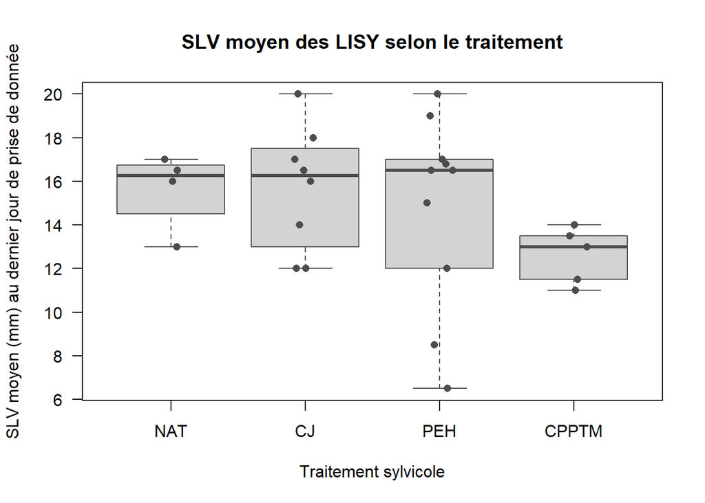

   ```r
   df$Traitement <- factor(df$Traitement,levels = c("NAT", "CJ", 'PEH', "CPPTM"))
   boxplot(LISY ~ Traitement,
           data = df,
           xlab = "Traitement sylvicole",
           ylab = 'SLV moyen (mm) au dernier jour de prise de donnée',
           main = "SLV moyen des LISY selon le traitement",
           border = "gray30",
           las = 1)
   stripchart(LISY ~ Traitement,
              data = df,
              vertical = TRUE,
              method = "jitter",
              pch = 16,
              col = "gray30",
              add = TRUE)
   ```

Clairement, rien n’est significatif. Pas super intéressant

Bref, en se basant sur l’effort de reproduction et le SLV, il ne semble pas y avoir de différence détectable entre les différents types de traitements.

## Est-ce que le nombre de larve varie selon le type de traitement sylvicole (CPUE) ?

Note: CPUE signifie Capture Per Unit Effort. Ici, le CPUE est représenté par le nombre de larves maximales attrapées / périmètre de l’étang (soit un coup d’épuisette = 1m).

### Ambystome :

1. **Préparation des données :**

   ```r
   df <-read_excel("C:/Users/super/Université du Québec en Outaouais/CLAUDIE ÉTANGS VERNAUX - Documents/Stats/Reproduction/Larves/CPUE.xlsx", sheet = 1)
   df <- df[df$amby != 0, ]
   df$X <- as.numeric(scale(df$X))
   df$Y <- as.numeric(scale(df$Y))
   df
   ```

   ```
   # A tibble: 16 × 16
      No_etang      Perimetre_cm Swipes Traitement  ANAM   amby anoure   DRVE  LICA
      <chr>                <dbl>  <dbl> <chr>      <dbl>  <dbl>  <dbl>  <dbl> <dbl>
    1 4WATCJ2              3280   32.8  CJ             0 0.884       0 0          0
    2 5WATCJ4              1640   16.4  CJ             0 0.0610      0 0          0
    3 6WATCJ3              2800   28    CJ             0 0.714       0 0          0
    4 10WATCPPTM5          3612.  36.1  CPPTM          0 0.0277      0 0.0277     0
    5 58WATCPPTMEX2        2088   20.9  CPPTM          0 0.0479      0 0          0
    6 24DORCJ11            1014   10.1  CJ             0 0.296       0 0          0
    7 25DORCJ12            8235   82.4  CJ             0 0.0729      0 0          0
    8 30DORPEH8             814.   8.14 PEH            0 0.860       0 0          0
    9 36DORCJ2             3160   31.6  CJ             0 0.0633      0 0          0
   10 40DORCJ8             9328   93.3  CJ             0 0.193       0 0          0
   11 45DORCPPTM7           883    8.83 CPPTM          0 1.81        0 0          0
   12 43DORCJ4             6081   60.8  CJ             0 0.0329      0 0          0
   13 50DORCPPTM3          7286   72.9  CPPTM          0 0.0137      0 0          0
   14 18FRONT5             3428.  34.3  NAT            0 4.26        0 0          0
   15 19FRONT5             2629.  26.3  NAT            0 0.685       0 0          0
   16 56MEGEX1             2954.  29.5  NAT            0 0.271       0 0          0
   # ℹ 7 more variables: LICL <dbl>, LISE <dbl>, LISY <dbl>, NOVI <dbl>,
   #   PSCR <dbl>, X <dbl>, Y <dbl>
   ```

2. **Visualisation :**

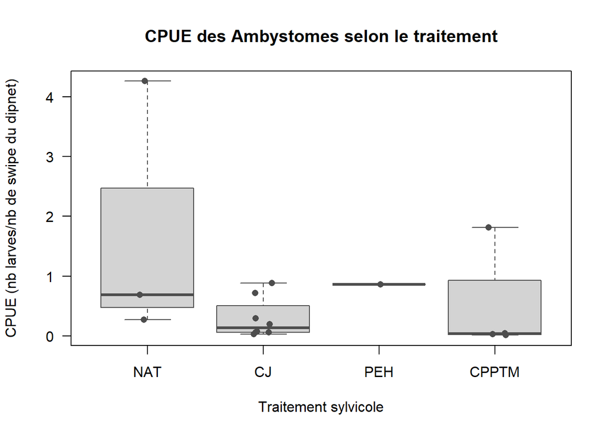

   ```r
   df$Traitement <- factor(df$Traitement,levels = c("NAT", "CJ", 'PEH', "CPPTM"))
   boxplot(amby ~ Traitement,
           data = df,
           xlab = "Traitement sylvicole",
           ylab = 'CPUE (nb larves/nb de swipe du dipnet)',
           main = "CPUE des Ambystomes selon le traitement",
           border = "gray30",
           las = 1)
   stripchart(amby ~ Traitement,
              data = df,
              vertical = TRUE,
              method = "jitter",
              pch = 16,
              col = "gray30",
              add = TRUE)
   ```

   n NAT=3, n CJ=8, n PEH= 1, n CPPTM= 4

   Encore une fois, pas beaucoup d’étangs et pas de pattern visible. Non significatif

### LISY :

1. **Préparation des données :**

   ```r
   df <-read_excel("C:/Users/super/Université du Québec en Outaouais/CLAUDIE ÉTANGS VERNAUX - Documents/Stats/Reproduction/Larves/CPUE.xlsx", sheet = 1)
   df <- df[df$LISY != 0, ]
   df <- df[df$No_etang != '18FRONT5', ] #Il est incroyablement plus élevé que les autres
   df$X <- as.numeric(scale(df$X))
   df$Y <- as.numeric(scale(df$Y))
   df
   ```

   ```
   # A tibble: 26 × 16
      No_etang      Perimetre_cm Swipes Traitement  ANAM   amby anoure   DRVE  LICA
      <chr>                <dbl>  <dbl> <chr>      <dbl>  <dbl>  <dbl>  <dbl> <dbl>
    1 5WATCJ4              1640   16.4  CJ             0 0.0610  0     0          0
    2 6WATCJ3              2800   28    CJ             0 0.714   0     0          0
    3 7WATPEH2             1106.  11.1  PEH            0 0       0     0          0
    4 12WATPEH5            2152.  21.5  PEH            0 0       0     0          0
    5 8WATPEH1              694.   6.94 PEH            0 0       0     0          0
    6 9WATPEH6              856.   8.56 PEH            0 0       0     0          0
    7 10WATCPPTM5          3612.  36.1  CPPTM          0 0.0277  0     0.0277     0
    8 59WATCJEX1           2276   22.8  CJ             0 0       0     0          0
    9 57WATPEHEX3           992.   9.92 PEH            0 0       0.806 0          0
   10 58WATCPPTMEX2        2088   20.9  CPPTM          0 0.0479  0     0          0
   # ℹ 16 more rows
   # ℹ 7 more variables: LICL <dbl>, LISE <dbl>, LISY <dbl>, NOVI <dbl>,
   #   PSCR <dbl>, X <dbl>, Y <dbl>
   ```

   18FRONT5 était trop élevé (environ 34.5) et qui rendait le graphique difficile à lire.
2. **Visualisation :**

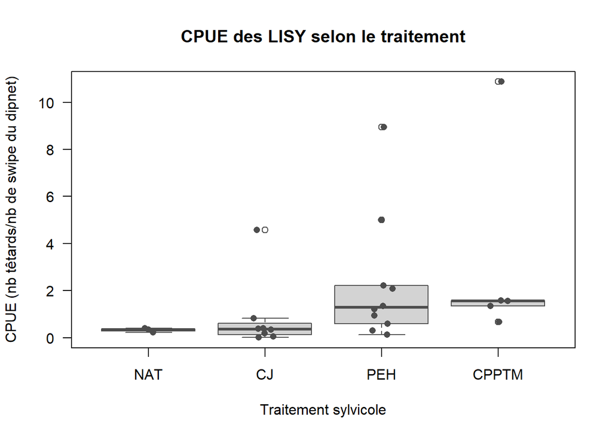

   ```r
   df$Traitement <- factor(df$Traitement,levels = c("NAT", "CJ", 'PEH', "CPPTM"))
   boxplot( LISY ~ Traitement,
           data = df,
           xlab = "Traitement sylvicole",
           ylab = 'CPUE (nb têtards/nb de swipe du dipnet)',
           main = "CPUE des LISY selon le traitement",
           border = "gray30",
           las = 1)
   stripchart(LISY ~ Traitement,
              data = df,
              vertical = TRUE,
              method = "jitter",
              pch = 16,
              col = "gray30",
              add = TRUE)
   ```

   Ici, il se pourrait que le CPUE de PEH et CPPTM soit plus élevé que celui de NAT et CJ ! Je vais faire une analyse pour confirmer
3. **Choix du modèle :**

   ```r
   library(lmtest)
   mod <- lm( LISY ~ Traitement + X + Y, data = df)
   shapiro.test(residuals(mod)) #Pas normal pentoute
   ```

   ```
       Shapiro-Wilk normality test

   data:  residuals(mod)
   W = 0.72583, p-value = 1.222e-05
   ```

   ```r
   bptest(mod) # Homogénéité ok
   ```

   ```
       studentized Breusch-Pagan test

   data:  mod
   BP = 3.6602, df = 5, p-value = 0.5993
   ```

   Avec un lm, on voit que les résiduts ne sont vraiment pas normaux. Va falloir passer au GLM  
   Puisque les CPUE sont positives, continues et asymétriques, on va opter pour la famille Gamma
4. **Analyse** :

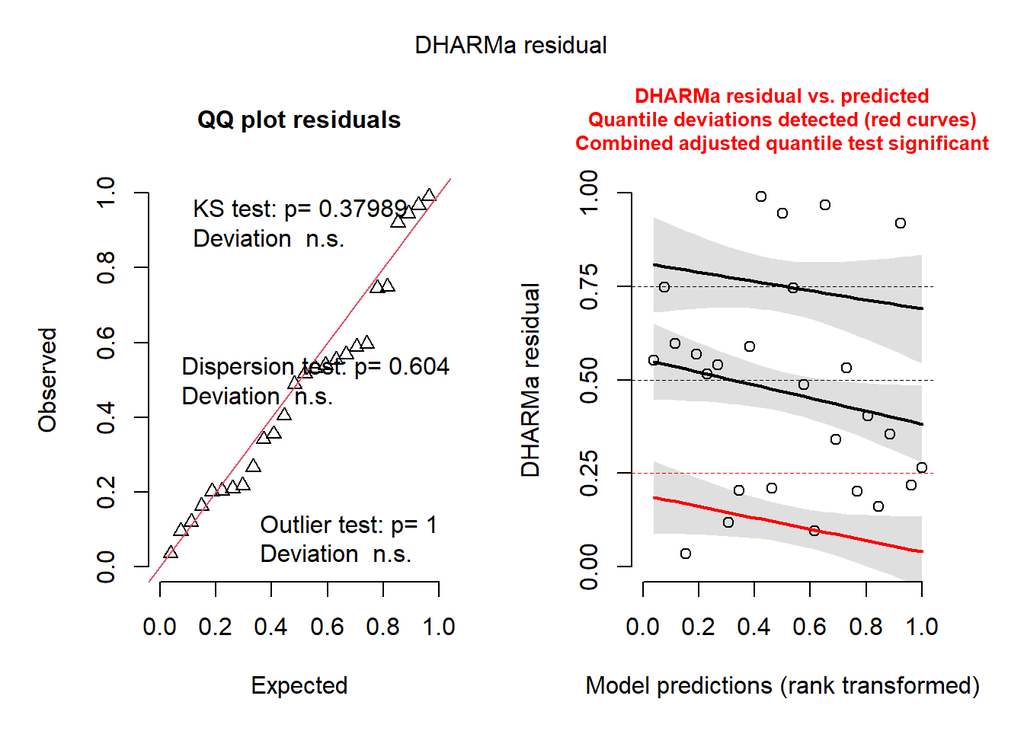

   ```r
   mod2 <- glm(LISY ~ Traitement + X + Y,data = df,family = Gamma(link = "log"))
   res <- simulateResiduals(fittedModel = mod2,n = 1000)
   plot(res)
   ```

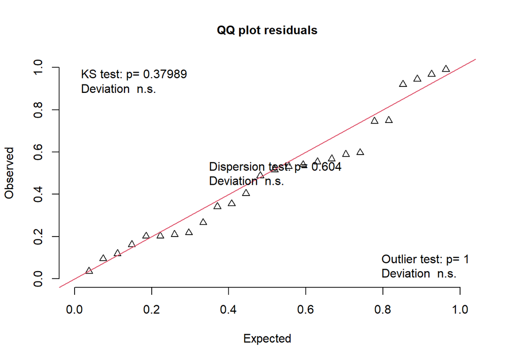

   ```
       Exact one-sample Kolmogorov-Smirnov test

   data:  simulationOutput$scaledResiduals
   D = 0.17223, p-value = 0.3799
   alternative hypothesis: two-sided
   ```

   ```r
   testUniformity(res) #ok
   ```

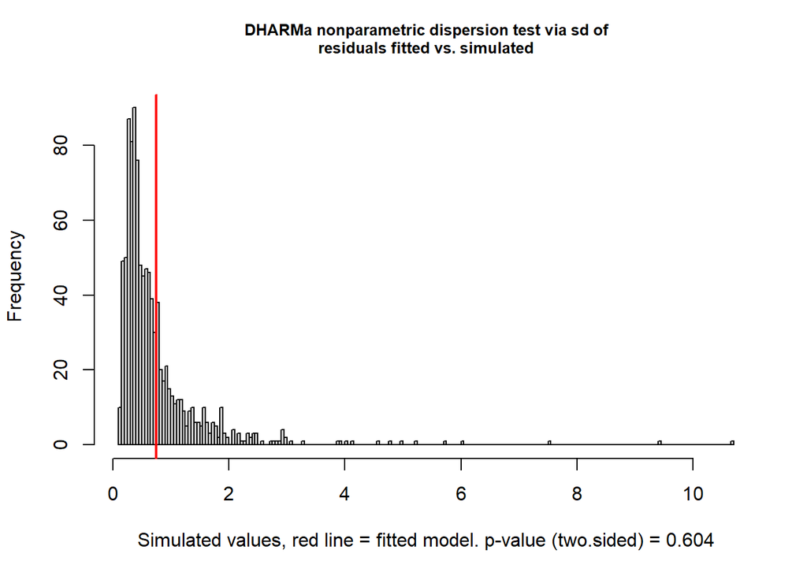

   ```
       DHARMa nonparametric dispersion test via sd of residuals fitted vs.
       simulated

   data:  simulationOutput
   dispersion = 1.0125, p-value = 0.604
   alternative hypothesis: two.sided
   ```

   ```r
   testDispersion(res) #ok
   ```

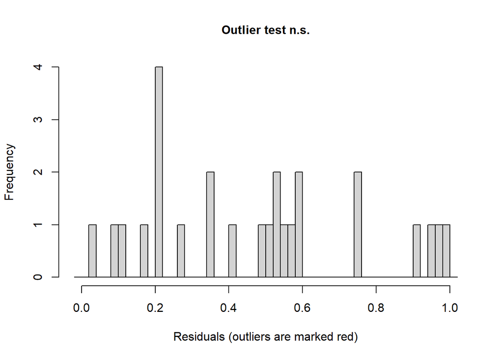

   ```
       DHARMa outlier test based on exact binomial test with approximate
       expectations

   data:  res
   outliers at both margin(s) = 0, observations = 26, p-value = 1
   alternative hypothesis: true probability of success is not equal to 0.001998002
   95 percent confidence interval:
    0.0000000 0.1322746
   sample estimates:
   frequency of outliers (expected: 0.001998001998002 )
                                                      0
   ```

   ```r
   testOutliers(res) #ok
   ```

   ```r
   summary(mod2) #Significatif, CPPTM vs CJ!
   ```

   ```
   Call:
   glm(formula = LISY ~ Traitement + X + Y, family = Gamma(link = "log"),
       data = df)

   Coefficients:
                   Estimate Std. Error t value Pr(>|t|)
   (Intercept)      -1.0097     1.0284  -0.982   0.3379
   TraitementCJ      0.6122     1.1861   0.516   0.6114
   TraitementPEH     1.7559     1.1643   1.508   0.1472
   TraitementCPPTM   2.3568     1.2581   1.873   0.0757 .
   X                -0.4536     0.7143  -0.635   0.5326
   Y                 0.1194     0.7520   0.159   0.8754
   ---
   Signif. codes:  0 '***' 0.001 '**' 0.01 '*' 0.05 '.' 0.1 ' ' 1

   (Dispersion parameter for Gamma family taken to be 1.835905)

       Null deviance: 47.911  on 25  degrees of freedom
   Residual deviance: 33.573  on 20  degrees of freedom
   AIC: 82.2

   Number of Fisher Scoring iterations: 18
   ```

   ```r
   emm <- emmeans(mod2, ~ Traitement, type = "response")
   emm
   ```

   ```
    Traitement response    SE df lower.CL upper.CL
    NAT           0.364 0.375 20   0.0426     3.11
    CJ            0.672 0.329 20   0.2421     1.87
    PEH           2.109 0.922 20   0.8471     5.25
    CPPTM         3.846 2.370 20   1.0640    13.90

   Confidence level used: 0.95
   Intervals are back-transformed from the log scale
   ```

   ```r
   pairs(emm, adjust = "holm") #la correction de holm rend le tout non significatif
   ```

   ```
    contrast     ratio    SE df null t.ratio p.value
    NAT / CJ    0.5421 0.643 20    1  -0.516  0.8561
    NAT / PEH   0.1728 0.201 20    1  -1.508  0.4415
    NAT / CPPTM 0.0947 0.119 20    1  -1.873  0.3786
    CJ / PEH    0.3187 0.207 20    1  -1.761  0.3786
    CJ / CPPTM  0.1747 0.136 20    1  -2.246  0.2171
    PEH / CPPTM 0.5483 0.407 20    1  -0.809  0.8561

   P value adjustment: holm method for 6 tests
   Tests are performed on the log scale
   ```

   ```r
   pairs(emm, adjust = "none")
   ```

   ```
    contrast     ratio    SE df null t.ratio p.value
    NAT / CJ    0.5421 0.643 20    1  -0.516  0.6114
    NAT / PEH   0.1728 0.201 20    1  -1.508  0.1472
    NAT / CPPTM 0.0947 0.119 20    1  -1.873  0.0757
    CJ / PEH    0.3187 0.207 20    1  -1.761  0.0935
    CJ / CPPTM  0.1747 0.136 20    1  -2.246  0.0362
    PEH / CPPTM 0.5483 0.407 20    1  -0.809  0.4281

   Tests are performed on the log scale
   ```

On a quelque chose de intéressant. Sans correction, il semblerait que le CPUE de CPPTM et CJ sont significativement différents. Par contre, avec correction, la significativité s’efface. Donc, à prendre avec un grain de sel. Par contre, il est intéressant de prendre en compte la tendance. Il semblerait avoir plus de têtards dans les traitements à couverture ouvertes (PEH et CPPTM) que dans les traitements à couverture fermées. Ceci pourrait être expliqué par le manque de prédation par les têtards de grenouilles vertes.

### Visuels combinés

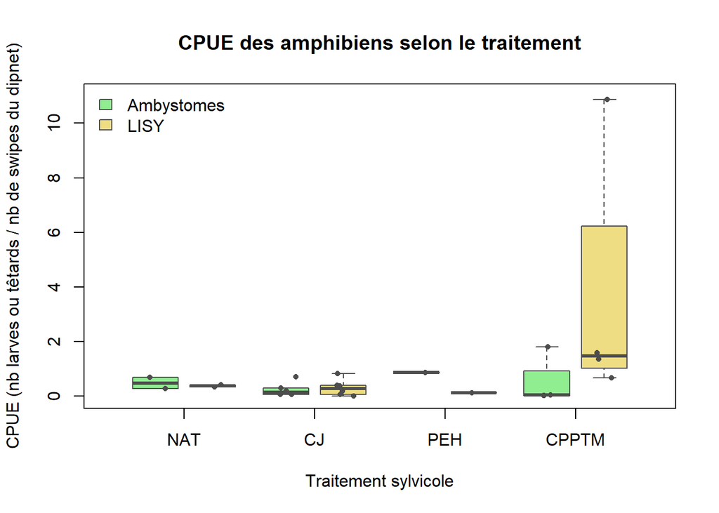

```r
df <-read_excel("C:/Users/super/Université du Québec en Outaouais/CLAUDIE ÉTANGS VERNAUX - Documents/Stats/Reproduction/Larves/CPUE.xlsx", sheet = 1)
df <- df[df$amby != 0, ]
df <- df[df$LISY != 0, ]
df <- df[df$No_etang != '18FRONT5', ] #Il est incroyablement plus élevé que les autres
df$Traitement <- factor(df$Traitement,levels = c("NAT", "CJ", "PEH", "CPPTM"))

# 1. Définir l'ordre des traitements
df$Traitement <- factor(df$Traitement,
                        levels = c("NAT", "CJ", "PEH", "CPPTM"))

# 2. Définir les positions des boîtes
pos <- 1:4
pos_amby <- pos - 0.22
pos_lisy <- pos + 0.22

# 3. Séparer les données par traitement
amby_liste <- split(df$amby, df$Traitement)
lisy_liste <- split(df$LISY, df$Traitement)

# 4. Créer le graphique
plot(NA,
     xlim = c(0.4, 4.6),
     ylim = c(0, 11),
     xaxt = "n",
     xlab = "Traitement sylvicole",
     ylab = "CPUE (nb larves ou têtards / nb de swipes du dipnet)",
     main = "CPUE des amphibiens selon le traitement")
axis(1, at = pos, labels = levels(df$Traitement))

# 5. Boîtes des Ambystomes
boxplot(amby_liste,
        at = pos_amby,
        add = TRUE,
        col = "lightgreen",
        border = "gray30",
        boxwex = 0.35,
        outline = FALSE,
        axes = FALSE)
stripchart(amby_liste,
           at = pos_amby,
           vertical = TRUE,
           method = "jitter",
           jitter = 0.08,
           pch = 16,
           cex = 0.7,
           col = "gray30",
           add = TRUE)

# 6. Boîtes des LISY
boxplot(lisy_liste,
        at = pos_lisy,
        add = TRUE,
        col = "lightgoldenrod",
        border = "gray30",
        boxwex = 0.35,
        outline = FALSE,
        axes = FALSE)
stripchart(lisy_liste,
           at = pos_lisy,
           vertical = TRUE,
           method = "jitter",
           jitter = 0.08,
           pch = 16,
           cex = 0.7,
           col = "gray30",
           add = TRUE)

# 7. Légende
legend("topleft",
       legend = c("Ambystomes", "LISY"),
       fill = c("lightgreen", "lightgoldenrod"),
       border = "gray30",
       bty = "n")
```

Il semblerait que le nombre de larves na varie pas vraiment entre Ambystome et LISY.

## Est-ce que la date de sortie (metamorphose) des larves varie selon le type de traitement ?

Devrait être similiaire aux résultats des SLV. Plus les larves sortent tardivement de l’étang, plus la qualité de celui-ci devrait être bonne. Ici, on va juste faire LISY puisqu’on a pas assez de métamorphose assurée pour les Ambystomes.

1. **Préparation des données** :

   ```r
   PS <- read_excel("C:/Users/super/Université du Québec en Outaouais/CLAUDIE ÉTANGS VERNAUX - Documents/Stats/Hydro_Survie/LISY_Database_Survie.xlsx", sheet = 1)
   PS <- PS[rowSums(!is.na(PS[, -1])) > 0, ]
   PS[PS == "NA"] <- NA
   PS <- filter(PS, !if_all(-No_etang, is.na))
   PS$No_etang <- as.factor(PS$No_etang)
   PS$AvantDer_prise <- as.numeric(PS$AvantDer_prise)
   PS$Der_prise <- as.numeric(PS$Der_prise)
   PS$Statut <- as.numeric(PS$Statut)
   PS$X <- as.numeric(PS$X)
   PS$Y <- as.numeric(PS$Y)
   PS$X <- as.numeric(scale(PS$X))
   PS$Y <- as.numeric(scale(PS$Y))
   PS$Condition <- as.factor(PS$Condition)
   PS$Traitements <- as.factor(PS$Traitements)
   PS <- PS[PS$Condition == "meta", ]
   PS$Temps_milieu <- ifelse(is.na(PS$Der_prise),PS$AvantDer_prise,(PS$AvantDer_prise + PS$Der_prise) / 2)
   ```

   Pour ‘’temps_milieu’’ note que avant cette ligne, j’ai seulement des intervals de temps entre lesquels dans la métamorphose c’est produit puisque je ne visitais pas mes étangs à chaques jours, mais en fait, à chaque deux semaines. Toutefois, les intervals ne sont pas idéales pour mes modèles. Alors, je décide de choisir la journée ‘’entre deux’’.
2. **Choix de l’analyse** :

   ```r
   mod <- lm(Temps_milieu ~ Traitements + X + Y, data = PS)
   shapiro.test(residuals(mod)) #Normalité ok
   ```

   ```
       Shapiro-Wilk normality test

   data:  residuals(mod)
   W = 0.96466, p-value = 0.5389
   ```

   ```r
   bptest(mod) # Homogénéité ok
   ```

   ```
       studentized Breusch-Pagan test

   data:  mod
   BP = 8.2366, df = 5, p-value = 0.1437
   ```

   Pas compliqué ici, le simple lm fonctionne très bien :)
3. **Analyse** :

   ```r
   summary(mod) #NAT très significatif!
   ```

   ```
   Call:
   lm(formula = Temps_milieu ~ Traitements + X + Y, data = PS)

   Residuals:
       Min      1Q  Median      3Q     Max
   -15.558  -3.306  -1.686   4.379  13.445

   Coefficients:
                    Estimate Std. Error t value Pr(>|t|)
   (Intercept)       195.168      3.116  62.633  < 2e-16 ***
   TraitementsCPPTM   -8.235      4.386  -1.877 0.076777 .
   TraitementsNAT     28.548      5.909   4.831 0.000134 ***
   TraitementsPEH     -3.653      4.498  -0.812 0.427366
   X                  -5.681      4.319  -1.315 0.204880
   Y                   8.721      4.413   1.976 0.063651 .
   ---
   Signif. codes:  0 '***' 0.001 '**' 0.01 '*' 0.05 '.' 0.1 ' ' 1

   Residual standard error: 8.124 on 18 degrees of freedom
   Multiple R-squared:  0.699, Adjusted R-squared:  0.6154
   F-statistic:  8.36 on 5 and 18 DF,  p-value: 0.0003116
   ```

   ```r
   emm <- emmeans(mod, ~ Traitements)
   pairs(emm, adjust = "tukey") #Nat diffère des autres!
   ```

   ```
    contrast    estimate   SE df t.ratio p.value
    CJ - CPPTM      8.23 4.39 18   1.877  0.2721
    CJ - NAT      -28.55 5.91 18  -4.831  0.0007
    CJ - PEH        3.65 4.50 18   0.812  0.8480
    CPPTM - NAT   -36.78 6.03 18  -6.095 <0.0001
    CPPTM - PEH    -4.58 4.45 18  -1.029  0.7353
    NAT - PEH      32.20 5.85 18   5.508  0.0002

   P value adjustment: tukey method for comparing a family of 4 estimates
   ```

   C’est très claire, la date de sortie des têtards de LISY est clairement plus élevé pour le traitement NAT
4. **Visualisation** :

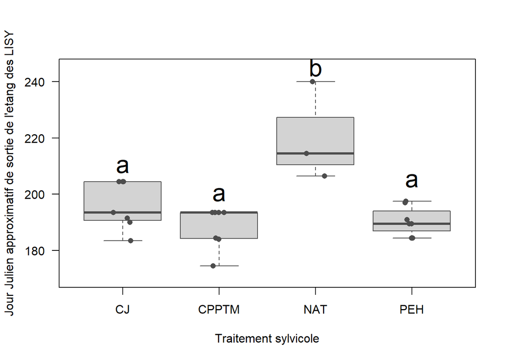

   ```r
   PS$Traitement <- factor(PS$Traitements,levels = c("NAT", "CJ", 'PEH', "CPPTM"))
   boxplot(Temps_milieu ~ Traitements,
           data = PS,
           xlab = "Traitement sylvicole",
           ylab = 'Jour Julien approximatif de sortie de l\'etang des LISY',
           border = "gray30",
           las = 1,
           ylim = c(170, 245))
   stripchart(Temps_milieu ~ Traitements,
              data = PS,
              vertical = TRUE,
              method = "jitter",
              pch = 16,
              col = "gray30",
              add = TRUE)
   text(x = 1, y = 210, labels = "a", cex = 2)
   text(x = 2, y = 200, labels = "a", cex = 2)
   text(x = 3, y = 245, labels = "b", cex = 2)
   text(x = 4, y = 205, labels = "a", cex = 2)
   ```

## Est-ce que le succès reproducteur (survit jusqu’à la métamorphose) varie selon le type de traitement ?

Note que toutes les mortalités inventoriées durant la période de terrain étaient reliées à une hydropériode trop courte à l’exception des mortalités dans les PEH qui sont un cas confirmé de Ranavirus par l’UQAM.

1. **Préparation des données** :

   | Code | Signification | Rôle |
   | --- | --- | --- |
   | 1 | Mort | Évènement d’intérêt |
   | 2 | Metamorphose | Risque compétitif |
   | 3 | Indéterminé | Risque compétitif |
   | 0 | Fin de la prise de données | Censure à droite |

   ```r
   PS <- read_excel("C:/Users/super/Université du Québec en Outaouais/CLAUDIE ÉTANGS VERNAUX - Documents/Stats/Hydro_Survie/FineGray_PoolSpecific_Database.xlsx", sheet = 1)
   PS[PS == "NA"] <- NA
   PS <- filter(PS, !if_all(-No_etang, is.na))
   PS$No_etang <- as.factor(PS$No_etang)
   PS$AvantDer_prise <- as.numeric(PS$AvantDer_prise)
   PS$Der_prise <- as.numeric(PS$Der_prise)
   PS$Statut <- as.numeric(PS$Statut)
   PS$Condition <- as.factor(PS$Condition)
   PS$Traitements <- as.factor(PS$Traitements)
   PS
   ```

   ```
   # A tibble: 54 × 6
      No_etang   AvantDer_prise Der_prise Statut Condition Traitements
      <fct>               <dbl>     <dbl>  <dbl> <fct>     <fct>
    1 1WATCJ6                37        NA      3 ind       CJ
    2 2WATCJ5                37        NA      3 ind       CJ
    3 3WATCJ1                51        61      1 mort      CJ
    4 4WATCJ2               110       127      1 mort      CJ
    5 5WATCJ4                93        NA      2 meta      CJ
    6 6WATCJ3               110       128      1 mort      CJ
    7 17WATPEH10             50        NA      3 ind       PEH
    8 7WATPEH2               92        NA      2 meta      PEH
    9 12WATPEH5              80        NA      2 meta      PEH
   10 8WATPEH1               93        NA      2 meta      PEH
   # ℹ 44 more rows
   ```

2. **Choix de l’analyse** :

   Ici, je dois modéliser les chances de mortalité à travers le temps en prenant compte que j’ai des évènements qui font ‘’competition’’ comme la métamorphose (la logique étant que si les amphibiens se métamorphosent dans l’étang, ils ne peuvent plus mourrir) en plus de censures à droite (des étangs qui ont ni séchés ni eux de métamorphose jusqu’à la fin de la prise de donnée.

   Le modèle de Cox n’est pas approprié pour cette situation puisqu’il ne permet pas d’avoir des évènements compétitifs comme la métamorphose. Ainsi, une analyse de Fine-Gray est la meilleure option que nous avons pour la situation.  
   Toutefois, si je veux utiliser Fine-Gray, je dois ajuster ma base de donnée. Présentement, j’ai plusieurs un intervals de temps dans lequel l’évènement c’est produit puisque je ne visitais pas mes étangs à chaques jours, mais en fait, à chaque deux semaines. Toutefois, Fine-Gray n’accepte pas les intervals. Alors, je décide de choisir la journée ‘’entre deux’’.

   ```r
   PS$Temps_milieu <- ifelse(is.na(PS$Der_prise),PS$AvantDer_prise,(PS$AvantDer_prise + PS$Der_prise) / 2)
   PS
   ```

   ```
   # A tibble: 54 × 7
      No_etang   AvantDer_prise Der_prise Statut Condition Traitements Temps_milieu
      <fct>               <dbl>     <dbl>  <dbl> <fct>     <fct>              <dbl>
    1 1WATCJ6                37        NA      3 ind       CJ                   37
    2 2WATCJ5                37        NA      3 ind       CJ                   37
    3 3WATCJ1                51        61      1 mort      CJ                   56
    4 4WATCJ2               110       127      1 mort      CJ                  118.
    5 5WATCJ4                93        NA      2 meta      CJ                   93
    6 6WATCJ3               110       128      1 mort      CJ                  119
    7 17WATPEH10             50        NA      3 ind       PEH                  50
    8 7WATPEH2               92        NA      2 meta      PEH                  92
    9 12WATPEH5              80        NA      2 meta      PEH                  80
   10 8WATPEH1               93        NA      2 meta      PEH                  93
   # ℹ 44 more rows
   ```

3. **Analyse** :

   ```r
   table(PS$Traitements, PS$Statut)
   ```

   ```
           0 1 2 3
     CJ    2 8 4 5
     CPPTM 3 4 4 4
     NAT   2 3 1 0
     PEH   2 0 7 5
   ```

   ```r
   PS$Traitements <- relevel(PS$Traitements, ref = "CJ")
   ```

   Ici, CJ a été choisi comme référence puisqu’il a beaucoup de mortalité. Si je choisi ‘’PEH’’ le modèle deviens instable puisqu’il se réfère à un traitement qui a 0 mortalité

   ```r
   library(survival)
   library(cmprsk)
   Trait2 <- model.matrix(~ Traitements, data = PS)[, -1]
   FG_mort2 <- crr(ftime = PS$Temps_milieu,fstatus = PS$Statut,cov1 = Trait2, failcode=1,cencode=0, maxiter = 100) #code de l'évènement d'intéret =1 mort par hydroperiode
   FG_mort2$converged
   ```

   ```
   [1] TRUE
   ```

   ```r
   summary(FG_mort2)
   ```

   ```
   Competing Risks Regression

   Call:
   crr(ftime = PS$Temps_milieu, fstatus = PS$Statut, cov1 = Trait2,
       failcode = 1, cencode = 0, maxiter = 100)

                       coef exp(coef) se(coef)       z p-value
   TraitementsCPPTM  -0.516  5.97e-01    0.588  -0.878    0.38
   TraitementsNAT     0.109  1.12e+00    0.625   0.175    0.86
   TraitementsPEH   -14.804  3.72e-07    0.434 -34.101    0.00

                    exp(coef) exp(-coef)     2.5%    97.5%
   TraitementsCPPTM  5.97e-01   1.68e+00 1.89e-01 1.89e+00
   TraitementsNAT    1.12e+00   8.97e-01 3.28e-01 3.80e+00
   TraitementsPEH    3.72e-07   2.69e+06 1.59e-07 8.71e-07

   Num. cases = 54
   Pseudo Log-likelihood = -50.9
   Pseudo likelihood ratio test = 11.8  on 3 df,
   ```

   Le modèle a effectivement convergé. Par contre, il n’est pas super fiable (coef de PEH = -14.804, c’est haut). Ceci découle de l’essence de mes données. J’ai retiré toutes les mortalités causées par le Ranavirus dans ma base de donnée de PEH. Ainsi, j’ai eux aucune autre mortalité. Puisque PEH a une mortalité de zéro, le modèle deviens instable, peu importe si j’augmente maxiter. C’est juste la nature des données.  
   Ici, on voit que PEH serait significativement différent comparé à CJ (à prendre avec précaution dut à l’instabilité du modèle). Il faut tester les autres types de traitements:

   ```r
   PS$Traitements <- relevel(PS$Traitements, ref = "CPPTM")
   Trait2 <- model.matrix(~ Traitements, data = PS)[, -1]
   FG_mort2 <- crr(ftime = PS$Temps_milieu,fstatus = PS$Statut,cov1 = Trait2, failcode=1,cencode=0, maxiter = 100) #code de l'évènement d'intéret =1 mort par hydroperiode
   FG_mort2$converged
   ```

   ```
   [1] TRUE
   ```

   ```r
   summary(FG_mort2) #PEH diffère de CPPTM
   ```

   ```
   Competing Risks Regression

   Call:
   crr(ftime = PS$Temps_milieu, fstatus = PS$Statut, cov1 = Trait2,
       failcode = 1, cencode = 0, maxiter = 100)

                     coef exp(coef) se(coef)       z p-value
   TraitementsCJ    0.516  1.68e+00    0.588   0.878    0.38
   TraitementsNAT   0.626  1.87e+00    0.705   0.888    0.37
   TraitementsPEH -14.288  6.23e-07    0.553 -25.846    0.00

                  exp(coef) exp(-coef)     2.5%    97.5%
   TraitementsCJ   1.68e+00   5.97e-01 5.30e-01 5.30e+00
   TraitementsNAT  1.87e+00   5.35e-01 4.70e-01 7.44e+00
   TraitementsPEH  6.23e-07   1.60e+06 2.11e-07 1.84e-06

   Num. cases = 54
   Pseudo Log-likelihood = -50.9
   Pseudo likelihood ratio test = 11.8  on 3 df,
   ```

   ```r
   PS$Traitements <- relevel(PS$Traitements, ref = "NAT")
   Trait2 <- model.matrix(~ Traitements, data = PS)[, -1]
   FG_mort2 <- crr(ftime = PS$Temps_milieu,fstatus = PS$Statut,cov1 = Trait2, failcode=1,cencode=0, maxiter = 100) #code de l'évènement d'intéret =1 mort par hydroperiode
   FG_mort2$converged
   ```

   ```
   [1] TRUE
   ```

   ```r
   summary(FG_mort2) #PEH diffère de NAT, tout les autres traitements se ressemblent!
   ```

   ```
   Competing Risks Regression

   Call:
   crr(ftime = PS$Temps_milieu, fstatus = PS$Statut, cov1 = Trait2,
       failcode = 1, cencode = 0, maxiter = 100)

                       coef exp(coef) se(coef)       z p-value
   TraitementsCPPTM  -0.626  5.35e-01    0.705  -0.888    0.37
   TraitementsCJ     -0.109  8.97e-01    0.625  -0.175    0.86
   TraitementsPEH   -14.914  3.34e-07    0.597 -24.973    0.00

                    exp(coef) exp(-coef)     2.5%    97.5%
   TraitementsCPPTM  5.35e-01   1.87e+00 1.34e-01 2.13e+00
   TraitementsCJ     8.97e-01   1.12e+00 2.63e-01 3.05e+00
   TraitementsPEH    3.34e-07   3.00e+06 1.03e-07 1.08e-06

   Num. cases = 54
   Pseudo Log-likelihood = -50.9
   Pseudo likelihood ratio test = 11.8  on 3 df,
   ```

   Avec ces résultats, le nombre de mortalité serait significativement plus basse dans PEH comparé à tous les autres types de traitements! La mortalité ne serait pas significativement différente entre les autres traitement.
4. **Visualisation** :

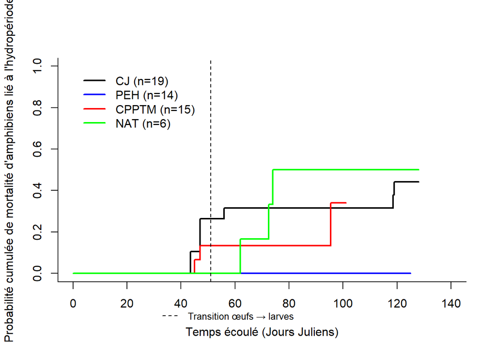

   ```r
   cif3<- with(PS,cuminc( ftime = Temps_milieu, fstatus = Statut, group = Traitements))
   plot(cif3[c("CJ 1","PEH 1","CPPTM 1","NAT 1")], lwd = 2,lty=rep(1,4),
        color=c('black','blue','red','green'),
        xlab = "Temps écoulé (Jours Juliens)",
        ylab = "Probabilité cumulée de mortalité d\'amphibiens lié à l'hydropériode",
        xlim=c(0,140),
        curvlab = NA,
        xaxt = "n")
   axis(side = 1,
        at = seq(0,140, by = 20))
   abline(v = 51, lty = 2)
   legend(x=0,y=1,
          legend = c("CJ (n=19)", "PEH (n=14)", "CPPTM (n=15)", "NAT (n=6)"),
          col = c('black','blue','red','green'),
          lwd = 2,
          bg = 'white',
          box.lty=0)
   legend(x=30, y = -0.15,
          legend = "Transition œufs → larves",
          lty = 2,
          bty = "n",
          xpd = TRUE,
          cex=0.8)
   ```

Plus la courbe est élevée, plus les probabilité de mourrir sont élevée. Ici, CPPTM s’arrête plus tôt puisque nous ne sommes pas été voir les étangs de CPPTM en août par limitations de terrain. Ici, on peut voir qu’il n’y a techniquement aucune chance de mourrir à cause d’une hydropériode trop courte pour les étangs de PEH, supporté par le modèle Fine-Gray (quoi que pas super fiable).

## PT.2 Est-ce que le succès reproducteur (survit jusqu’à la métamorphose) varie selon le type de traitement ?

Je n’ai pas été satisfaite du modèle Fine-Gray pour la mortalité. Il n’était pas stable puisque PEH a 0 mortalité. J’ai donc essayé de nouveau avec un évènement qui est présent dans TOUT les traitements: la métamorphose.  
Donc, pour ce cas, la mortalité sera un évènement compétitif et la métamorphose est l’évènement d’intérêt!

1. **Préparation des données:**

   ```r
   PS <- read_excel("C:/Users/super/Université du Québec en Outaouais/CLAUDIE ÉTANGS VERNAUX - Documents/Stats/Hydro_Survie/FineGray_PoolSpecific_Database.xlsx", sheet = 1)
   PS[PS == "NA"] <- NA
   PS <- filter(PS, !if_all(-No_etang, is.na))
   PS$No_etang <- as.factor(PS$No_etang)
   PS$AvantDer_prise <- as.numeric(PS$AvantDer_prise)
   PS$Der_prise <- as.numeric(PS$Der_prise)
   PS$Statut <- as.numeric(PS$Statut)
   PS$Condition <- as.factor(PS$Condition)
   PS$Traitements <- as.factor(PS$Traitements)
   PS$Temps_milieu <- ifelse(is.na(PS$Der_prise),PS$AvantDer_prise,(PS$AvantDer_prise + PS$Der_prise) / 2)
   PS
   ```

   ```
   # A tibble: 54 × 7
      No_etang   AvantDer_prise Der_prise Statut Condition Traitements Temps_milieu
      <fct>               <dbl>     <dbl>  <dbl> <fct>     <fct>              <dbl>
    1 1WATCJ6                37        NA      3 ind       CJ                   37
    2 2WATCJ5                37        NA      3 ind       CJ                   37
    3 3WATCJ1                51        61      1 mort      CJ                   56
    4 4WATCJ2               110       127      1 mort      CJ                  118.
    5 5WATCJ4                93        NA      2 meta      CJ                   93
    6 6WATCJ3               110       128      1 mort      CJ                  119
    7 17WATPEH10             50        NA      3 ind       PEH                  50
    8 7WATPEH2               92        NA      2 meta      PEH                  92
    9 12WATPEH5              80        NA      2 meta      PEH                  80
   10 8WATPEH1               93        NA      2 meta      PEH                  93
   # ℹ 44 more rows
   ```

2. **Analyse :**

```r
PS$Traitements <- relevel(PS$Traitements, ref = "PEH")
Trait2 <- model.matrix(~ Traitements, data = PS)[, -1]
FG_meta2 <- crr(ftime = PS$Temps_milieu,fstatus = PS$Statut,cov1 = Trait2, failcode=2,cencode=0, maxiter = 100) #code de l'évènement d'intéret =2 métamorphose
FG_meta2$converged
```

```
[1] TRUE
```

```r
summary(FG_meta2)
```

```
Competing Risks Regression

Call:
crr(ftime = PS$Temps_milieu, fstatus = PS$Statut, cov1 = Trait2,
    failcode = 2, cencode = 0, maxiter = 100)

                   coef exp(coef) se(coef)      z p-value
TraitementsCJ    -0.971     0.379    0.594 -1.634    0.10
TraitementsCPPTM -0.548     0.578    0.621 -0.883    0.38
TraitementsNAT   -1.292     0.275    0.987 -1.309    0.19

                 exp(coef) exp(-coef)   2.5% 97.5%
TraitementsCJ        0.379       2.64 0.1182  1.21
TraitementsCPPTM     0.578       1.73 0.1712  1.95
TraitementsNAT       0.275       3.64 0.0397  1.90

Num. cases = 54
Pseudo Log-likelihood = -59
Pseudo likelihood ratio test = 3.31  on 3 df,
```

```r
PS$Traitements <- relevel(PS$Traitements, ref = "CJ")
Trait2 <- model.matrix(~ Traitements, data = PS)[, -1]
FG_meta2 <- crr(ftime = PS$Temps_milieu,fstatus = PS$Statut,cov1 = Trait2, failcode=2,cencode=0, maxiter = 100)
FG_meta2$converged
```

```
[1] TRUE
```

```r
summary(FG_meta2)
```

```
Competing Risks Regression

Call:
crr(ftime = PS$Temps_milieu, fstatus = PS$Statut, cov1 = Trait2,
    failcode = 2, cencode = 0, maxiter = 100)

                   coef exp(coef) se(coef)      z p-value
TraitementsPEH    0.971     2.640    0.594  1.634    0.10
TraitementsCPPTM  0.422     1.526    0.707  0.597    0.55
TraitementsNAT   -0.321     0.725    1.050 -0.306    0.76

                 exp(coef) exp(-coef)   2.5% 97.5%
TraitementsPEH       2.640      0.379 0.8237  8.46
TraitementsCPPTM     1.526      0.655 0.3814  6.10
TraitementsNAT       0.725      1.379 0.0926  5.68

Num. cases = 54
Pseudo Log-likelihood = -59
Pseudo likelihood ratio test = 3.31  on 3 df,
```

```r
PS$Traitements <- relevel(PS$Traitements, ref = "CPPTM")
Trait2 <- model.matrix(~ Traitements, data = PS)[, -1]
FG_meta2 <- crr(ftime = PS$Temps_milieu,fstatus = PS$Statut,cov1 = Trait2, failcode=2,cencode=0, maxiter = 100)
FG_meta2$converged
```

```
[1] TRUE
```

```r
summary(FG_meta2)
```

```
Competing Risks Regression

Call:
crr(ftime = PS$Temps_milieu, fstatus = PS$Statut, cov1 = Trait2,
    failcode = 2, cencode = 0, maxiter = 100)

                 coef exp(coef) se(coef)      z p-value
TraitementsCJ  -0.422     0.655    0.707 -0.597    0.55
TraitementsPEH  0.548     1.730    0.621  0.883    0.38
TraitementsNAT -0.744     0.475    1.054 -0.706    0.48

               exp(coef) exp(-coef)   2.5% 97.5%
TraitementsCJ      0.655      1.526 0.1639  2.62
TraitementsPEH     1.730      0.578 0.5124  5.84
TraitementsNAT     0.475      2.104 0.0602  3.75

Num. cases = 54
Pseudo Log-likelihood = -59
Pseudo likelihood ratio test = 3.31  on 3 df,
```

```r
PS$Traitements <- relevel(PS$Traitements, ref = "NAT")
Trait2 <- model.matrix(~ Traitements, data = PS)[, -1]
FG_meta2 <- crr(ftime = PS$Temps_milieu,fstatus = PS$Statut,cov1 = Trait2, failcode=2,cencode=0, maxiter = 100)
FG_meta2$converged
```

```
[1] TRUE
```

```r
summary(FG_meta2)
```

```
Competing Risks Regression

Call:
crr(ftime = PS$Temps_milieu, fstatus = PS$Statut, cov1 = Trait2,
    failcode = 2, cencode = 0, maxiter = 100)

                  coef exp(coef) se(coef)     z p-value
TraitementsCPPTM 0.744      2.10    1.054 0.706    0.48
TraitementsCJ    0.321      1.38    1.050 0.306    0.76
TraitementsPEH   1.292      3.64    0.987 1.309    0.19

                 exp(coef) exp(-coef)  2.5% 97.5%
TraitementsCPPTM      2.10      0.475 0.266  16.6
TraitementsCJ         1.38      0.725 0.176  10.8
TraitementsPEH        3.64      0.275 0.526  25.2

Num. cases = 54
Pseudo Log-likelihood = -59
Pseudo likelihood ratio test = 3.31  on 3 df,
```

Ici, les coef sont beaucoup plus beau. Les modèles sont plus stables. Contrairement à l’analyse de mortalité, rien est significatif. Aucun traitement aurait plus de chances de métamorphoses que les autres.

3. **Visualisation**

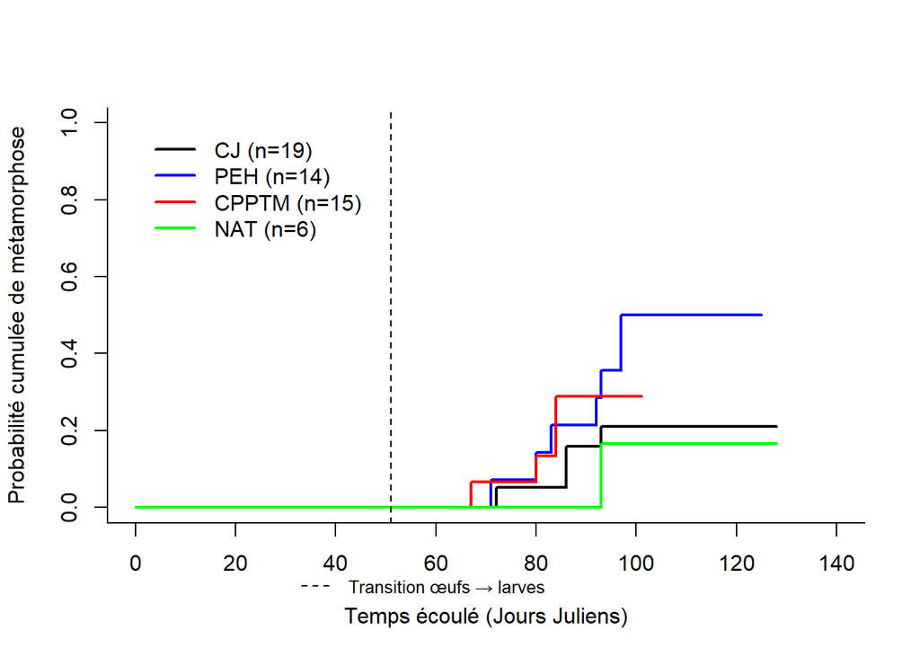

   ```r
   cif3<- with(PS,cuminc( ftime = Temps_milieu, fstatus = Statut, group = Traitements))
   plot(cif3[c("CJ 2","PEH 2","CPPTM 2","NAT 2")], lwd = 2,lty=rep(1,4),
        color=c('black','blue','red','green'),
        xlab = "Temps écoulé (Jours Juliens)",
        ylab = "Probabilité cumulée de métamorphose",
        xlim=c(0,140),
        curvlab = NA,
        xaxt = "n")
   axis(side = 1,
        at = seq(0,140, by = 20))
   abline(v = 51, lty = 2)
   legend(x=0,y=1,
          legend = c("CJ (n=19)", "PEH (n=14)", "CPPTM (n=15)", "NAT (n=6)"),
          col = c('black','blue','red','green'),
          lwd = 2,
          bg = 'white',
          box.lty=0)
   legend(x=30, y = -0.15,
          legend = "Transition œufs → larves",
          lty = 2,
          bty = "n",
          xpd = TRUE,
          cex=0.8)
   ```

Bien que non significatif, on voit ici la même tendance qu’on a vu dans les mortalités. Il semblerait que les chances de métamorphoses dans PEH est relativement plus élevée que les autres, étant, surpenament, NAT qui a le moins de chances. Ceci est probablement dut que 3 de mes 6 échantillons sont morts à cause de l’année exceptionnellement sèche.

4. **Conclusion**

   La littérature semble expliquer qu’une mortalité élevé durant une sécheresse en nature est frequemment observée. C’est pourquoi que les ambystomes et LISY pondent aussi dans les étangs permanants. C’est juste que, dans des années mouillées ou sans sécheresse, ceux qui ont opté pour les étangs vernaux auraient plus de succès reproducteur.  
   Ici, on a une situation de sécheresse, ce qui explique les résultats et ce qui est inquiétant pour le futur des amphibiens forestier puisqu’on prédit une météo de plus en plus instable. Les PEH vont être très utile pour les LISY mais inquiétant pour les ambystomes

# Conclusion :

Bien que la mortalité dut à l’hydropériode est élevée dans les NAT, pour les naturels étangs qui garde plus d’eau, les LISY peuvent prendre beaucoup plus de temps avant de sortir de l’étang. Ceci est intéressant, surtout sachant que les PEH garde l’eau très longtemps mais, les LISY décident de sortir tout de même rapidement. La présence de grenouilles vertes pourrait en être la cause (prédation / compétition). Peu importe la longueur de l’hydropériode, les conditions de NAT sont tout de même exceptionnels. Surprenament, le SLV de NAT n’était pas plus élevé que les autres, ce qui contredit un peu la littérature.  
Un résultat qui a aussi été non attendu: aucun traitement n’est ressortis significatif pour l’effort de reproduction (oeufs). C’est pourtant sur les études qui exploraient quels éléments environnementaux affecte cet aspect sur lesquels je me suis inspirée pour choisir mes valeurs environnementales à évaluer pour mon étude.

Avec les analyses de Fine-Gray, on voit que les chances de mortalité pour LISY dans les PEH est très bas. Du moins, lorsque la plantation est jeune, les étangs créés par la machinerie aide au recrutement des anoures (quoi qu’ils sont completement innaccesible pour les ambystomes à cause de la canopée trop ouverte). Toutefois, si l’étang conserve assez longtemps, les chances de métamorphose des PEH n’est pas nécessairement plus élevé qu’ailleurs. Donc le facteur limitant les chances de métamorphoses n’est pas nécessairement la compétition / prédation par les autres espèces (grenouille vertes et rainette crucifère), c’est en fait l’hydropériode.